# IODS course project

Mikko Niemi, University of Helsinki

# Introduction to Open Data Science - Course Project

### About the project

**Wow!!** I am excited to see what I will learn in this course, and especially what I can publish using these tools in future. I found the course via the study program of *AGFOREE Doctoral School*, and this is a part of my PhD studies.

> [Link to my GitHub repository](https://github.com/Mikko-Niemi/IODS-project)

```r
# I already know R statistics quite well, but the version control and publishing possibilities are interesting.
# Since the summer is over and weather is changing more rainy, it's good time to learn some coding :-)
date()
```

```
## [1] "Tue Dec 01 11:56:27 2020"
```

So, let’s go!

# WEEK 2: Student’s attitude versus exam points

- In this exercise I had a data set that described student’s attitude on statistics versus student’s success at statistics exam.
- The data contained total **7 variables**: (1) gender, (2) age, (3) global attitude towards statistics, adjusted indexes on (4) deep approach, (5) strategic approach and (6) surface approach, and (7) exam points.
- The data contained total **166 students**: 110 female and 56 male.
- Student’s attitude towards statistics and exam points correlate significantly, and I managed to make a model that described 20,5 % of the variation of exam points by two variables: student’s attitude and strategic approach. See the results and their interpretations below:

```r
# Set working directory:
setwd("C:/Users/mikniemi/OneDrive - University of Helsinki/OpenDataScience/IODS/IODS-project")

# Read the data called "learning2014.txt":
learning2014 <- read.table("Data/learning2014.txt", sep="\t", header=TRUE)

# Access necessary libraries:
library(ggplot2)
library(GGally)
# Look at the structure of the data:
str(learning2014)
```

```
## 'data.frame':    166 obs. of  7 variables:
##  $ gender  : chr  "F" "M" "F" "M" ...
##  $ age     : int  53 55 49 53 49 38 50 37 37 42 ...
##  $ attitude: int  37 31 25 35 37 38 35 29 38 21 ...
##  $ deep    : num  3.58 2.92 3.5 3.5 3.67 ...
##  $ stra    : num  3.38 2.75 3.62 3.12 3.62 ...
##  $ surf    : num  2.58 3.17 2.25 2.25 2.83 ...
##  $ points  : int  25 12 24 10 22 21 21 31 24 26 ...
```

```r
# And the dimensions:
dim(learning2014)
```

```
## [1] 166   7
```

```r
# See 5 first rows of the data:
head(learning2014, 5)
```

```
##   gender age attitude     deep  stra     surf points
## 1      F  53       37 3.583333 3.375 2.583333     25
## 2      M  55       31 2.916667 2.750 3.166667     12
## 3      F  49       25 3.500000 3.625 2.250000     24
## 4      M  53       35 3.500000 3.125 2.250000     10
## 5      M  49       37 3.666667 3.625 2.833333     22
```

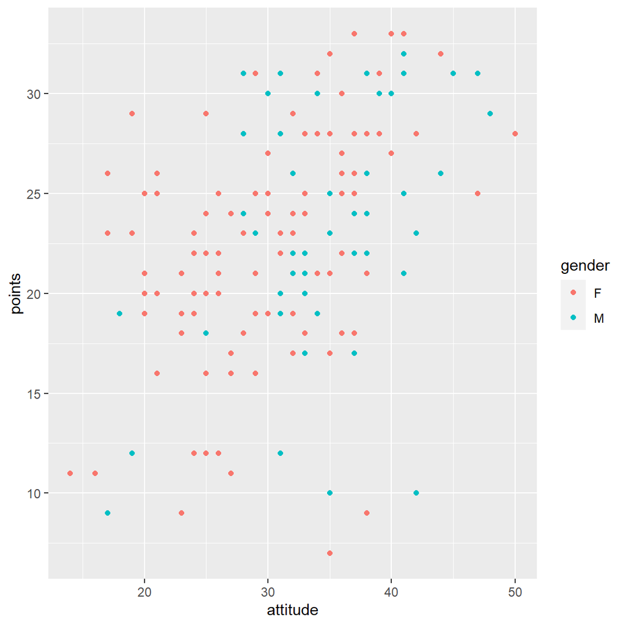

```r
# Look at a plot that describes student's attitude versus exam points:
ggplot(learning2014, aes(x = attitude, y = points, col = gender)) + geom_point()
```

```r
# Summary of the data: see the distributions of the variables
# - There seems the be a positive correlation between the global attitude on statistics and exam points.
summary(learning2014)
```

```
##     gender               age           attitude          deep
##  Length:166         Min.   :17.00   Min.   :14.00   Min.   :1.583
##  Class :character   1st Qu.:21.00   1st Qu.:26.00   1st Qu.:3.333
##  Mode  :character   Median :22.00   Median :32.00   Median :3.667
##                     Mean   :25.51   Mean   :31.43   Mean   :3.680
##                     3rd Qu.:27.00   3rd Qu.:37.00   3rd Qu.:4.083
##                     Max.   :55.00   Max.   :50.00   Max.   :4.917
##       stra            surf           points
##  Min.   :1.250   Min.   :1.583   Min.   : 7.00
##  1st Qu.:2.625   1st Qu.:2.417   1st Qu.:19.00
##  Median :3.188   Median :2.833   Median :23.00
##  Mean   :3.121   Mean   :2.787   Mean   :22.72
##  3rd Qu.:3.625   3rd Qu.:3.167   3rd Qu.:27.75
##  Max.   :5.000   Max.   :4.333   Max.   :33.00
```

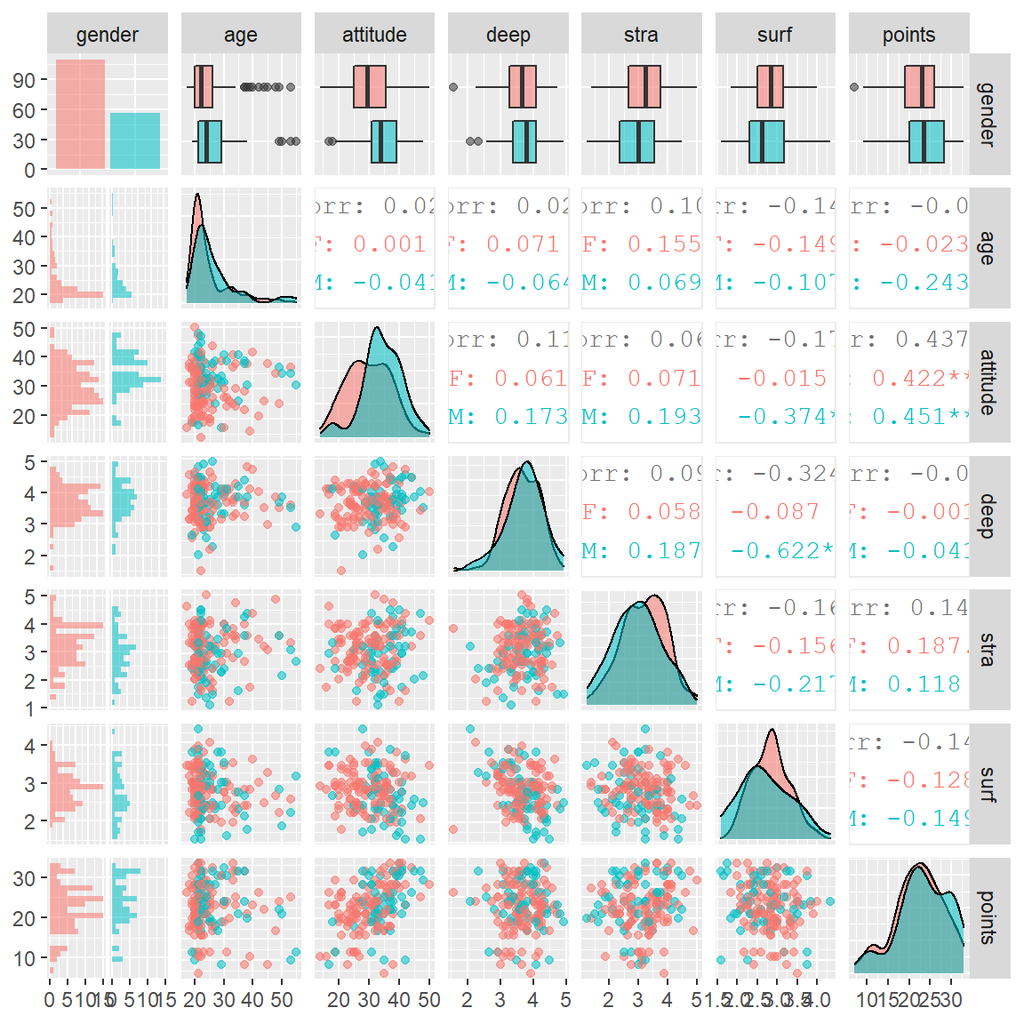

```r
# Exploring the relations between the variables by creating an advanced plot matrix
ggpairs(learning2014, mapping = aes(col = gender, alpha = 0.3), lower = list(combo = wrap("facethist", bins = 20)))
```

```r
# According to the correlation values, I chose variables *attitude*, *strategic approach* and *surface approach* as explanatory variables for a linear regression model targeting exam points:
my_model <- lm(points ~ attitude + stra + surf, data = learning2014)
summary(my_model)
```

```
##
## Call:
## lm(formula = points ~ attitude + stra + surf, data = learning2014)
##
## Residuals:
##      Min       1Q   Median       3Q      Max
## -17.1550  -3.4346   0.5156   3.6401  10.8952
##
## Coefficients:
##             Estimate Std. Error t value Pr(>|t|)
## (Intercept) 11.01711    3.68375   2.991  0.00322 **
## attitude     0.33952    0.05741   5.913 1.93e-08 ***
## stra         0.85313    0.54159   1.575  0.11716
## surf        -0.58607    0.80138  -0.731  0.46563
## ---
## Signif. codes:  0 '***' 0.001 '**' 0.01 '*' 0.05 '.' 0.1 ' ' 1
##
## Residual standard error: 5.296 on 162 degrees of freedom
## Multiple R-squared:  0.2074, Adjusted R-squared:  0.1927
## F-statistic: 14.13 on 3 and 162 DF,  p-value: 3.156e-08
```

```r
# According to the summary above, attitude has strong significance in the model, but variables "stra" and "surf" have lower significance. Next I tried to exclude variable "surf" (p value 0.466) from the model:
my_model2 <- lm(points ~ attitude + stra, data = learning2014)
summary(my_model2)
```

```
##
## Call:
## lm(formula = points ~ attitude + stra, data = learning2014)
##
## Residuals:
##      Min       1Q   Median       3Q      Max
## -17.6436  -3.3113   0.5575   3.7928  10.9295
##
## Coefficients:
##             Estimate Std. Error t value Pr(>|t|)
## (Intercept)  8.97290    2.39591   3.745  0.00025 ***
## attitude     0.34658    0.05652   6.132 6.31e-09 ***
## stra         0.91365    0.53447   1.709  0.08927 .
## ---
## Signif. codes:  0 '***' 0.001 '**' 0.01 '*' 0.05 '.' 0.1 ' ' 1
##
## Residual standard error: 5.289 on 163 degrees of freedom
## Multiple R-squared:  0.2048, Adjusted R-squared:  0.1951
## F-statistic: 20.99 on 2 and 163 DF,  p-value: 7.734e-09
```

```
## [1] "Tue Dec 01 11:56:33 2020"
```

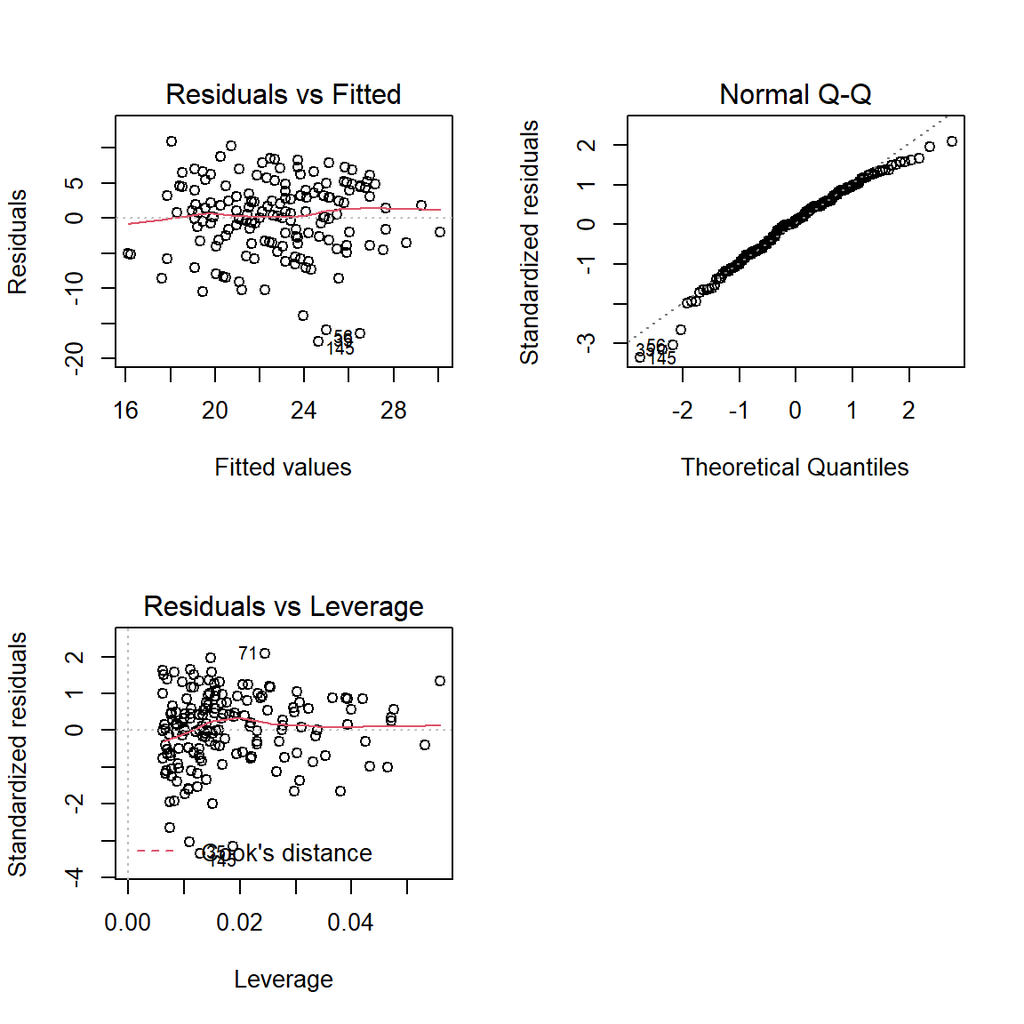

```r
# The intercept and the variable attitude are clearly significant in the model.
# Significance of the variable "stra" depends on decision maker's risk level.
# There is a risk of 9 % that this data was acquired, but exam points do not rely on variable "stra" at all.

# Multiple R-squared means that 20,48 % of the total variation in exam points can be explained by this model.
# R-squared is always between 0-1, and the higher the value is, the better the model explains variation.

# Plotting residuals versus fitted values, normal QQ-plot and residuals versus leverage:
par(mfrow = c(2,2))
plot(my_model2, which = c(1,2,5))

# In linear regression we assume that residuals are normally distributed and the size of the errors do not depend and explanatory variables.
# The plot of Residuals versus Fitted values shows that there is no trend between these values, which is good.
# The better points fill in the line of Normal Q-Q plot, the better this fit to the normality assumption of residuals, and in here this works quite well.
# The plot of Residuals versus Leverage shows how much single observations affect to model parameters and here we see that there is no single observation having extremely strong impact.

date()
```

This was a good exercise, and I really learned a lot of these statistical tests. And I am sure that I will take this ggplot2-package for regular use since now I learned how useful it is! :-)

# WEEK 3: Logistic regression

In this exercise I had a data set that included statistics on student’s social background, living place, education, alcohol consumption etc. versus student’s grades and absences in Mathematics and Portuguese language.

Related study: *P. Cortez and A. Silva. Using Data Mining to Predict Secondary School Student Performance. In A. Brito and J. Teixeira Eds., Proceedings of 5th FUture BUsiness TEChnology Conference (FUBUTEC 2008) pp. 5-12, Porto, Portugal, April, 2008, EUROSIS, ISBN 978-9077381-39-7.*

Web link: [http://www3.dsi.uminho.pt/pcortez/student.pdf]

```r
alc <- read.table("Data/alc.txt")
colnames(alc)
```

```
##  [1] "school"     "sex"        "age"        "address"    "famsize"
##  [6] "Pstatus"    "Medu"       "Fedu"       "Mjob"       "Fjob"
## [11] "reason"     "guardian"   "traveltime" "studytime"  "schoolsup"
## [16] "famsup"     "activities" "nursery"    "higher"     "internet"
## [21] "romantic"   "famrel"     "freetime"   "goout"      "Dalc"
## [26] "Walc"       "health"     "failures"   "paid"       "absences"
## [31] "G1"         "G2"         "G3"         "alc_use"    "high_use"
```

The data contains total 35 variables: both social and school related features. The most interesting variable related to student’s performance is ‘G3’, which is a mean of final year grades of Mathematics and Portuguese language. Attribute ‘alc_use’ equals to average alcohol consumption, and students having average consumption of higher than 2 were classified as high users (value TRUE at column ‘high_use’).

### Study questions:

Let’s examine if there are relationships between high/low alcohol consumption and student’s (1) **sex**, (2) **weekly study time**, (3) **extra-curricular activities** and (4) **final grade**. - I hypothesize that either sex or study time don’t relate on alcohol consumption, but I believe that having extra-curricular activities would decrease alcohol consumption. Also I believe that high alcohol use would decrease student’s final grade.

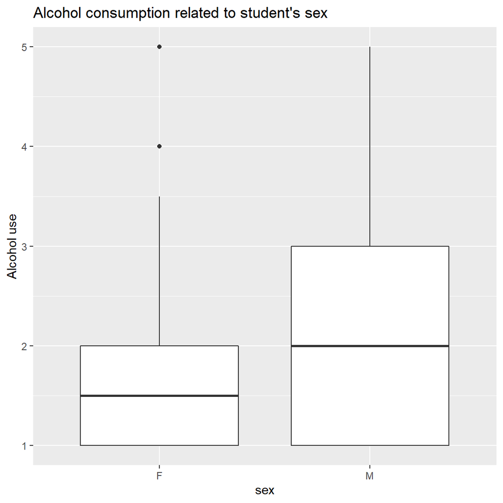

```r
# Explore relationship between sex and alcohol consumption:
g1 <- ggplot(alc, aes(x = sex, y = alc_use))
g1 + geom_boxplot() + ggtitle("Alcohol consumption related to student's sex") + ylab("Alcohol use")
```

Damn, I went totally wrong here, since according to the figure above male students consume significantly more alcohol than female students on average. Let’s then explore if weekly study time matters on alcohol use:

```r
# Explore relationship between weekly study time and alcohol consumption:
alc %>% group_by(studytime) %>% summarise(count = n(), alcohol = mean(alc_use))
```

```
## # A tibble: 4 x 3
##   studytime count alcohol
##       <int> <int>   <dbl>
## 1         1    98    2.27
## 2         2   185    1.86
## 3         3    60    1.52
## 4         4    27    1.54
```

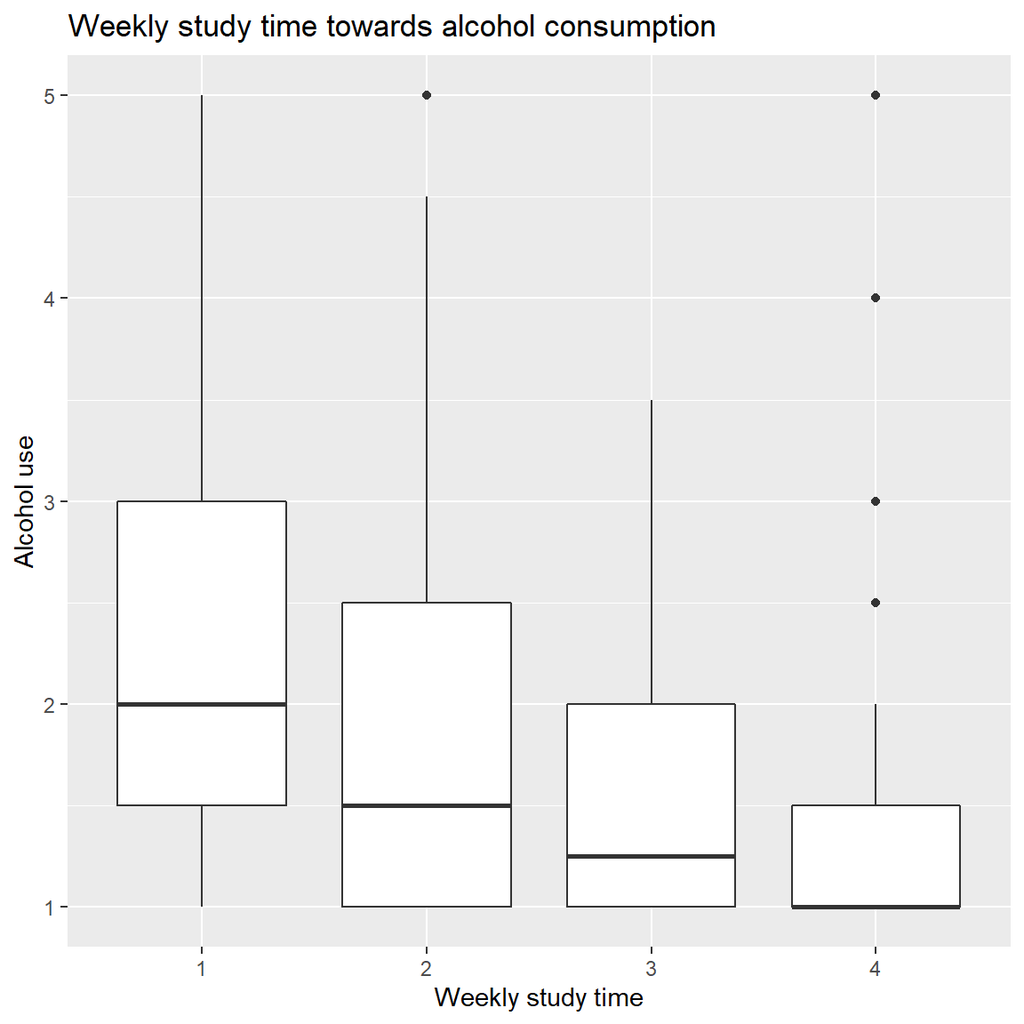

```r
g2 <- ggplot(alc, aes(x = factor(studytime), y = alc_use))
g2 + geom_boxplot() + ggtitle("Weekly study time towards alcohol consumption") + ylab("Alcohol use") + xlab("Weekly study time")
```

The criteria: 1 = <2 hours, 2 = 2 to 5 hours, 3 = 5 to 10 hours, or 4 =- >10 hours.

So, the less they study, the more they drink. Or the more they drink, the less they study? I cannot know if there exists a causal relationship between study time and alcohol consumption, but in any case the figure above points out that on average people using more time for studying are drinking less. How about extra-curricular activities:

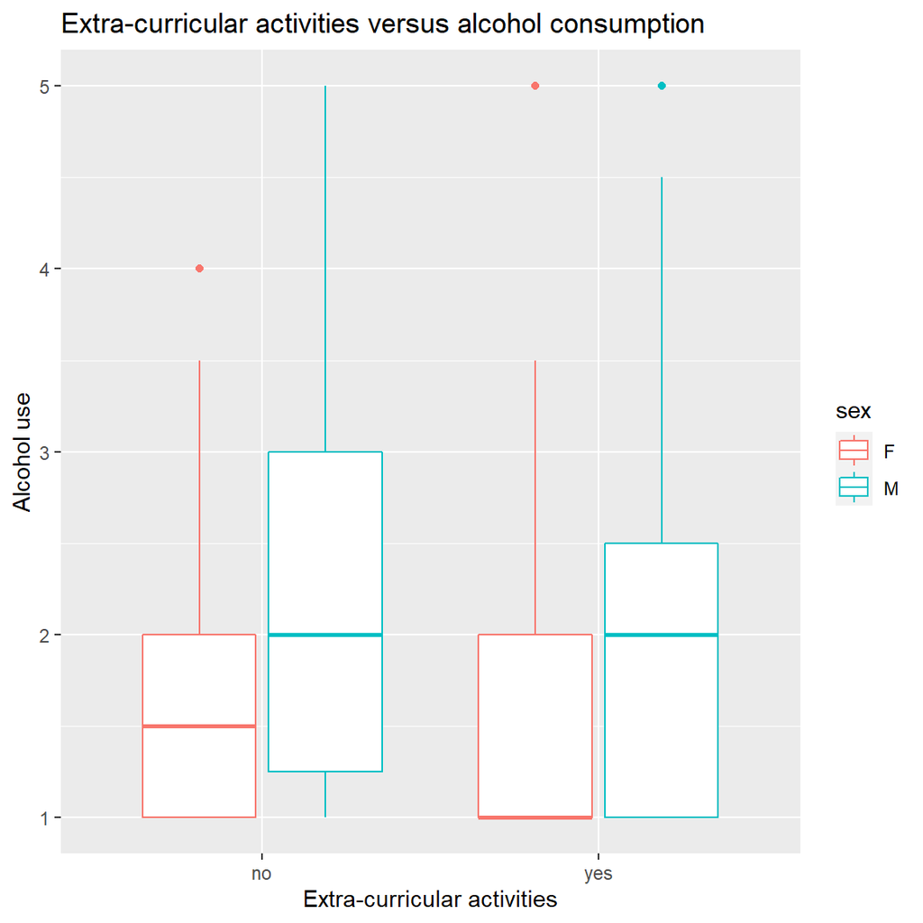

```r
# Explore relationship between extra-curricular activities and alcohol consumption:
g3 <- ggplot(alc, aes(x = activities, y = alc_use, col = sex))
g3 + geom_boxplot() + ggtitle("Extra-curricular activities versus alcohol consumption") + ylab("Alcohol use") + xlab("Extra-curricular activities")
```

I hypothesized that having extra-curricular activities would decrease drinking, but this figure is against my thoughts. Either female or male don’t have significant difference here. My assumptions have been too bad… The last guess was that alcohol consumption would decrease final grade.

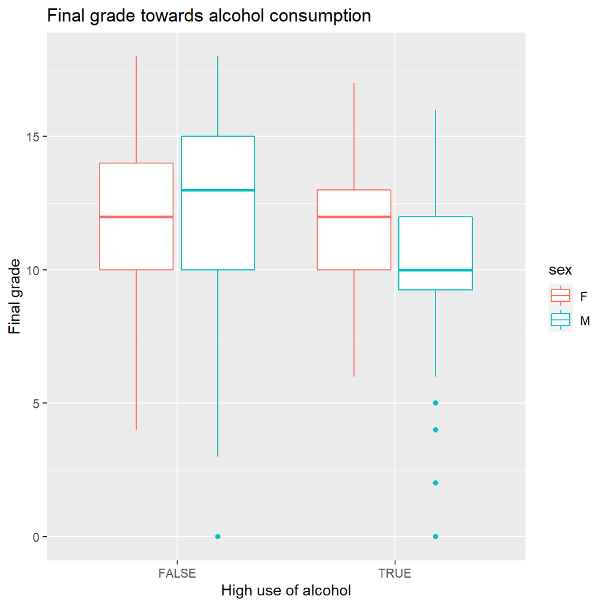

```r
# Explore relationship between final grade and alcohol consumption:
g4 <- ggplot(alc, aes(x = high_use, y = G3, col = sex))
g4 + geom_boxplot() + ggtitle("Final grade towards alcohol consumption") + xlab("High use of alcohol") + ylab("Final grade")
```

Interesting: Male students who drink a lot, have got significantly lower grades than they who are not high-users. But female students have got approximately equal grades whether they are high-users or not. So the combination of sex and final grade might help us to predict high-users by logistic regression.

### Logistic regression model:

```r
# Fit logistic regression model:
m1 <- glm(high_use ~ sex + studytime + activities + G3, data = alc, family = "binomial")
summary(m1)
```

```
##
## Call:
## glm(formula = high_use ~ sex + studytime + activities + G3, family = "binomial",
##     data = alc)
##
## Deviance Residuals:
##     Min       1Q   Median       3Q      Max
## -1.5618  -0.8334  -0.6514   1.1705   2.1916
##
## Coefficients:
##               Estimate Std. Error z value Pr(>|z|)
## (Intercept)    0.51218    0.52022   0.985  0.32485
## sexM           0.77704    0.25030   3.104  0.00191 **
## studytime     -0.41957    0.16027  -2.618  0.00885 **
## activitiesyes -0.26007    0.24134  -1.078  0.28120
## G3            -0.07127    0.03680  -1.937  0.05278 .
## ---
## Signif. codes:  0 '***' 0.001 '**' 0.01 '*' 0.05 '.' 0.1 ' ' 1
##
## (Dispersion parameter for binomial family taken to be 1)
##
##     Null deviance: 452.04  on 369  degrees of freedom
## Residual deviance: 420.16  on 365  degrees of freedom
## AIC: 430.16
##
## Number of Fisher Scoring iterations: 4
```

```r
# Compute odds ratios (OR)
OR <- coef(m1) %>% exp

# Compute confidence intervals (CI)
CI <- confint(m1) %>% exp

# Print out the odds ratios with their confidence intervals
cbind(OR, CI)
```

```
##                      OR     2.5 %    97.5 %
## (Intercept)   1.6689249 0.6053506 4.6794065
## sexM          2.1750354 1.3356996 3.5699532
## studytime     0.6573270 0.4756858 0.8933087
## activitiesyes 0.7709957 0.4793976 1.2367785
## G3            0.9312065 0.8655560 1.0003113
```

In the table above I have presented odds ratios and their intervals for different explanatory variables. The odds ratios tell us for example that if student is male, his probability to be alcohol high-user is 2.175 times larger than female students. If odds ratio is less than 1 (like study time), then it’s less probable to be high-user. And if value 1 is between the confidence interval (like activities), then there is no significant evidence that having extra-curricular activities would decrease the probability being high-user.

```r
# Fit logistic regression model without non-significant variable activities:
m2 <- glm(high_use ~ sex + studytime + G3, data = alc, family = "binomial")
summary(m2)
```

```
##
## Call:
## glm(formula = high_use ~ sex + studytime + G3, family = "binomial",
##     data = alc)
##
## Deviance Residuals:
##     Min       1Q   Median       3Q      Max
## -1.5174  -0.8425  -0.6723   1.1643   2.2607
##
## Coefficients:
##             Estimate Std. Error z value Pr(>|z|)
## (Intercept)  0.47034    0.51713   0.910  0.36308
## sexM         0.74089    0.24742   2.994  0.00275 **
## studytime   -0.44010    0.15938  -2.761  0.00576 **
## G3          -0.07402    0.03664  -2.020  0.04334 *
## ---
## Signif. codes:  0 '***' 0.001 '**' 0.01 '*' 0.05 '.' 0.1 ' ' 1
##
## (Dispersion parameter for binomial family taken to be 1)
##
##     Null deviance: 452.04  on 369  degrees of freedom
## Residual deviance: 421.33  on 366  degrees of freedom
## AIC: 429.33
##
## Number of Fisher Scoring iterations: 4
```

```r
# Explore the predictive power of the model m2, first predict the probability of high_use:
probabilities <- predict(m2, type = "response")

# Add the predicted probabilities to 'alc':
alc <- mutate(alc, probability = probabilities)

# Use the probabilities to make a prediction of high_use:
alc <- mutate(alc, prediction = probability > 0.5)

# Tabulate the target variable versus the predictions:
table(high_use = alc$high_use, prediction = alc$prediction) %>% addmargins()
```

```
##         prediction
## high_use FALSE TRUE Sum
##    FALSE   246   13 259
##    TRUE     91   20 111
##    Sum     337   33 370
```

```r
# Tabulate percentages:
table(high_use = alc$high_use, prediction = alc$prediction) %>% prop.table() %>% addmargins()
```

```
##         prediction
## high_use      FALSE       TRUE        Sum
##    FALSE 0.66486486 0.03513514 0.70000000
##    TRUE  0.24594595 0.05405405 0.30000000
##    Sum   0.91081081 0.08918919 1.00000000
```

Thus, 246/259 not high-users were predicted correctly, but only 20/111 high-users were predicted correctly.

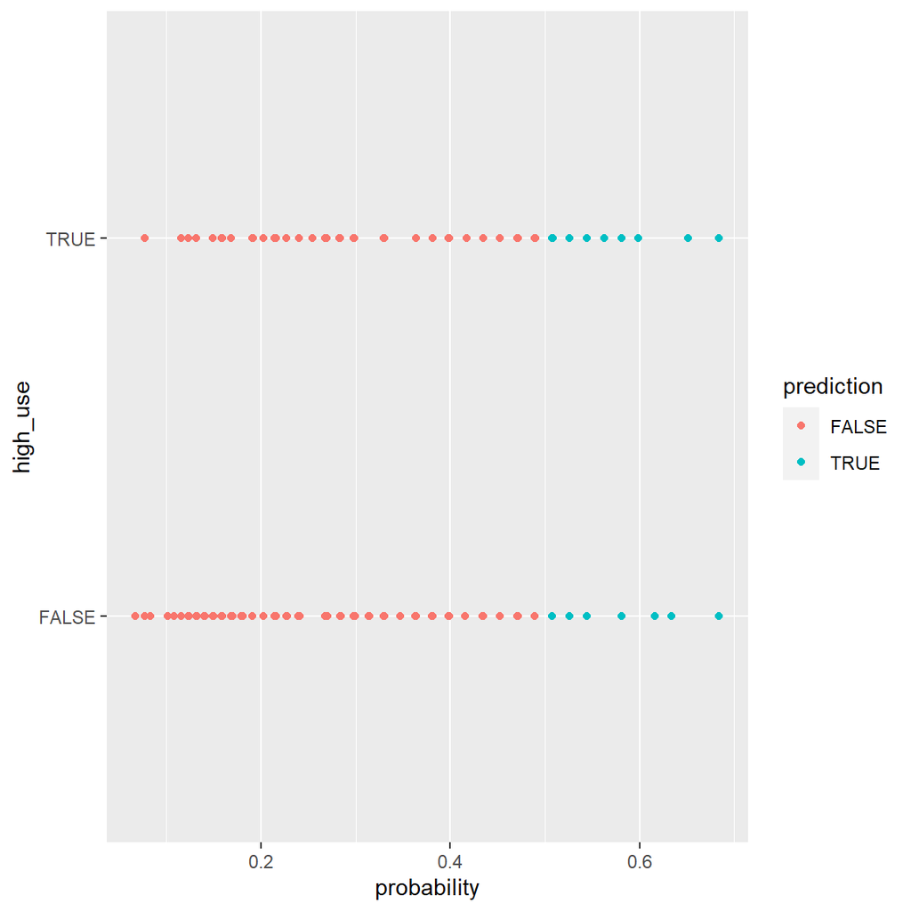

```r
# Initialize a plot of 'high_use' versus 'probability' in 'alc'
g <- ggplot(alc, aes(x = probability, y = high_use, col = prediction))

# define the geom as points and draw the plot
g + geom_point()
```

In the figure above the same phenomena is illustrated. Generally the model underestimates alcohol use, and it doesn’t recognize all high-users.

```r
# Let's then define a loss function (= mean prediction error)
loss_func <- function(class, prob) {
  n_wrong <- abs(class - prob) > 0.5
  mean(n_wrong)
}

# Call loss function to compute the average number of wrong predictions in the (training) data
loss_func(class = alc$high_use, prob = alc$probability)
```

```
## [1] 0.2810811
```

```r
# And compare the previous result to a prediction that there would have been zero high-users:
loss_func(class = alc$high_use, prob = 0)
```

```
## [1] 0.3
```

My model went wrong 28.1 % of times, but a very simple prediction would go wrong 30 % of times. Therefore my predictions were only slightly better. Having a real case I should consider testing other explanatory variables too.

# WEEK 4: Clustering and classification

In this exercise I used a data of **Housing Values in Suburbs of Boston** that was freely available in the MASS package. The data contains 506 rows (=different suburbs) and 14 columns (=variables). The variables try to explain different criteria of live quality in Boston suburbs. See the details [here](https://stat.ethz.ch/R-manual/R-devel/library/MASS/html/Boston.html).

```r
# Access the necessary tool packages:
library(MASS)
library(corrplot)
library(dplyr)
library(ggplot2)

# Load the Boston data:
data("Boston")

# Explore the data:
str(Boston)
```

```
## 'data.frame':    506 obs. of  14 variables:
##  $ crim   : num  0.00632 0.02731 0.02729 0.03237 0.06905 ...
##  $ zn     : num  18 0 0 0 0 0 12.5 12.5 12.5 12.5 ...
##  $ indus  : num  2.31 7.07 7.07 2.18 2.18 2.18 7.87 7.87 7.87 7.87 ...
##  $ chas   : int  0 0 0 0 0 0 0 0 0 0 ...
##  $ nox    : num  0.538 0.469 0.469 0.458 0.458 0.458 0.524 0.524 0.524 0.524 ...
##  $ rm     : num  6.58 6.42 7.18 7 7.15 ...
##  $ age    : num  65.2 78.9 61.1 45.8 54.2 58.7 66.6 96.1 100 85.9 ...
##  $ dis    : num  4.09 4.97 4.97 6.06 6.06 ...
##  $ rad    : int  1 2 2 3 3 3 5 5 5 5 ...
##  $ tax    : num  296 242 242 222 222 222 311 311 311 311 ...
##  $ ptratio: num  15.3 17.8 17.8 18.7 18.7 18.7 15.2 15.2 15.2 15.2 ...
##  $ black  : num  397 397 393 395 397 ...
##  $ lstat  : num  4.98 9.14 4.03 2.94 5.33 ...
##  $ medv   : num  24 21.6 34.7 33.4 36.2 28.7 22.9 27.1 16.5 18.9 ...
```

```r
summary(Boston)
```

```
##       crim                zn             indus            chas
##  Min.   : 0.00632   Min.   :  0.00   Min.   : 0.46   Min.   :0.00000
##  1st Qu.: 0.08205   1st Qu.:  0.00   1st Qu.: 5.19   1st Qu.:0.00000
##  Median : 0.25651   Median :  0.00   Median : 9.69   Median :0.00000
##  Mean   : 3.61352   Mean   : 11.36   Mean   :11.14   Mean   :0.06917
##  3rd Qu.: 3.67708   3rd Qu.: 12.50   3rd Qu.:18.10   3rd Qu.:0.00000
##  Max.   :88.97620   Max.   :100.00   Max.   :27.74   Max.   :1.00000
##       nox               rm             age              dis
##  Min.   :0.3850   Min.   :3.561   Min.   :  2.90   Min.   : 1.130
##  1st Qu.:0.4490   1st Qu.:5.886   1st Qu.: 45.02   1st Qu.: 2.100
##  Median :0.5380   Median :6.208   Median : 77.50   Median : 3.207
##  Mean   :0.5547   Mean   :6.285   Mean   : 68.57   Mean   : 3.795
##  3rd Qu.:0.6240   3rd Qu.:6.623   3rd Qu.: 94.08   3rd Qu.: 5.188
##  Max.   :0.8710   Max.   :8.780   Max.   :100.00   Max.   :12.127
##       rad              tax           ptratio          black
##  Min.   : 1.000   Min.   :187.0   Min.   :12.60   Min.   :  0.32
##  1st Qu.: 4.000   1st Qu.:279.0   1st Qu.:17.40   1st Qu.:375.38
##  Median : 5.000   Median :330.0   Median :19.05   Median :391.44
##  Mean   : 9.549   Mean   :408.2   Mean   :18.46   Mean   :356.67
##  3rd Qu.:24.000   3rd Qu.:666.0   3rd Qu.:20.20   3rd Qu.:396.23
##  Max.   :24.000   Max.   :711.0   Max.   :22.00   Max.   :396.90
##      lstat            medv
##  Min.   : 1.73   Min.   : 5.00
##  1st Qu.: 6.95   1st Qu.:17.02
##  Median :11.36   Median :21.20
##  Mean   :12.65   Mean   :22.53
##  3rd Qu.:16.95   3rd Qu.:25.00
##  Max.   :37.97   Max.   :50.00
```

```r
# Calculate the correlation matrix and round it:
cor_matrix <- cor(Boston) %>% round(2)
cor_matrix
```

```
##          crim    zn indus  chas   nox    rm   age   dis   rad   tax ptratio
## crim     1.00 -0.20  0.41 -0.06  0.42 -0.22  0.35 -0.38  0.63  0.58    0.29
## zn      -0.20  1.00 -0.53 -0.04 -0.52  0.31 -0.57  0.66 -0.31 -0.31   -0.39
## indus    0.41 -0.53  1.00  0.06  0.76 -0.39  0.64 -0.71  0.60  0.72    0.38
## chas    -0.06 -0.04  0.06  1.00  0.09  0.09  0.09 -0.10 -0.01 -0.04   -0.12
## nox      0.42 -0.52  0.76  0.09  1.00 -0.30  0.73 -0.77  0.61  0.67    0.19
## rm      -0.22  0.31 -0.39  0.09 -0.30  1.00 -0.24  0.21 -0.21 -0.29   -0.36
## age      0.35 -0.57  0.64  0.09  0.73 -0.24  1.00 -0.75  0.46  0.51    0.26
## dis     -0.38  0.66 -0.71 -0.10 -0.77  0.21 -0.75  1.00 -0.49 -0.53   -0.23
## rad      0.63 -0.31  0.60 -0.01  0.61 -0.21  0.46 -0.49  1.00  0.91    0.46
## tax      0.58 -0.31  0.72 -0.04  0.67 -0.29  0.51 -0.53  0.91  1.00    0.46
## ptratio  0.29 -0.39  0.38 -0.12  0.19 -0.36  0.26 -0.23  0.46  0.46    1.00
## black   -0.39  0.18 -0.36  0.05 -0.38  0.13 -0.27  0.29 -0.44 -0.44   -0.18
## lstat    0.46 -0.41  0.60 -0.05  0.59 -0.61  0.60 -0.50  0.49  0.54    0.37
## medv    -0.39  0.36 -0.48  0.18 -0.43  0.70 -0.38  0.25 -0.38 -0.47   -0.51
##         black lstat  medv
## crim    -0.39  0.46 -0.39
## zn       0.18 -0.41  0.36
## indus   -0.36  0.60 -0.48
## chas     0.05 -0.05  0.18
## nox     -0.38  0.59 -0.43
## rm       0.13 -0.61  0.70
## age     -0.27  0.60 -0.38
## dis      0.29 -0.50  0.25
## rad     -0.44  0.49 -0.38
## tax     -0.44  0.54 -0.47
## ptratio -0.18  0.37 -0.51
## black    1.00 -0.37  0.33
## lstat   -0.37  1.00 -0.74
## medv     0.33 -0.74  1.00
```

See the summary and the correlation matrix of the data above. For example we can notice that e.g. crime rate varies very much among the suburbs: the highest crime rate is even 89 %. I would also like to highlight large variations at air quality (nox = nitrogen oxides concentration), percent of lower status of the population (lstat), and proportion of blacks by town. Charles River (chas) is the only dummy variable there (= 1 if tract bounds river; 0 otherwise).

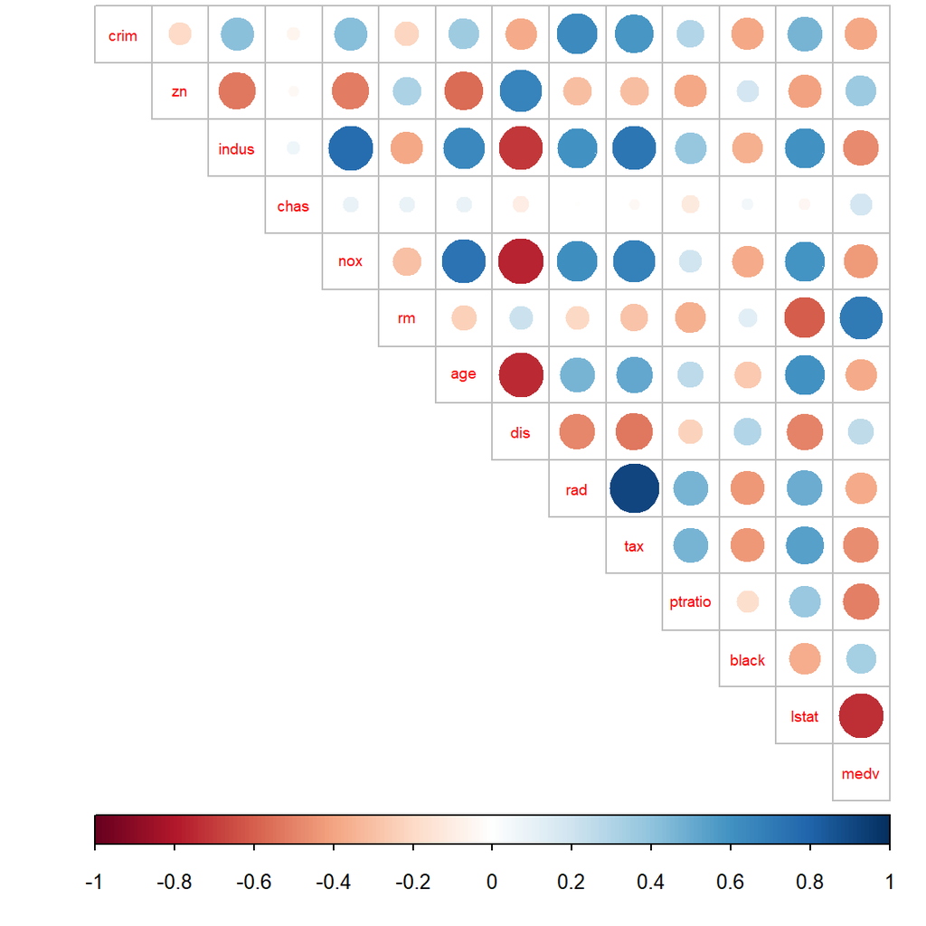

```r
# Visualize the correlation matrix:
corrplot(cor_matrix, method="circle", type="upper", cl.pos="b", tl.pos="d", tl.cex=0.6)
```

Here is the most beautiful illustration of correlation matrix that I have ever seen! You can copy the code above and use it, please! I don’t believe the figure needs any explanation, since it’s so good… :-)

### Standardizing the data and splitting it to train (80 %) and test (20 %) sets

```r
# Center and standardize variables, see the summaries, and change the object to data frame, and remove the dummy variable:
boston_scaled <- scale(Boston)
summary(boston_scaled)
```

```
##       crim                 zn               indus              chas
##  Min.   :-0.419367   Min.   :-0.48724   Min.   :-1.5563   Min.   :-0.2723
##  1st Qu.:-0.410563   1st Qu.:-0.48724   1st Qu.:-0.8668   1st Qu.:-0.2723
##  Median :-0.390280   Median :-0.48724   Median :-0.2109   Median :-0.2723
##  Mean   : 0.000000   Mean   : 0.00000   Mean   : 0.0000   Mean   : 0.0000
##  3rd Qu.: 0.007389   3rd Qu.: 0.04872   3rd Qu.: 1.0150   3rd Qu.:-0.2723
##  Max.   : 9.924110   Max.   : 3.80047   Max.   : 2.4202   Max.   : 3.6648
##       nox                rm               age               dis
##  Min.   :-1.4644   Min.   :-3.8764   Min.   :-2.3331   Min.   :-1.2658
##  1st Qu.:-0.9121   1st Qu.:-0.5681   1st Qu.:-0.8366   1st Qu.:-0.8049
##  Median :-0.1441   Median :-0.1084   Median : 0.3171   Median :-0.2790
##  Mean   : 0.0000   Mean   : 0.0000   Mean   : 0.0000   Mean   : 0.0000
##  3rd Qu.: 0.5981   3rd Qu.: 0.4823   3rd Qu.: 0.9059   3rd Qu.: 0.6617
##  Max.   : 2.7296   Max.   : 3.5515   Max.   : 1.1164   Max.   : 3.9566
##       rad               tax             ptratio            black
##  Min.   :-0.9819   Min.   :-1.3127   Min.   :-2.7047   Min.   :-3.9033
##  1st Qu.:-0.6373   1st Qu.:-0.7668   1st Qu.:-0.4876   1st Qu.: 0.2049
##  Median :-0.5225   Median :-0.4642   Median : 0.2746   Median : 0.3808
##  Mean   : 0.0000   Mean   : 0.0000   Mean   : 0.0000   Mean   : 0.0000
##  3rd Qu.: 1.6596   3rd Qu.: 1.5294   3rd Qu.: 0.8058   3rd Qu.: 0.4332
##  Max.   : 1.6596   Max.   : 1.7964   Max.   : 1.6372   Max.   : 0.4406
##      lstat              medv
##  Min.   :-1.5296   Min.   :-1.9063
##  1st Qu.:-0.7986   1st Qu.:-0.5989
##  Median :-0.1811   Median :-0.1449
##  Mean   : 0.0000   Mean   : 0.0000
##  3rd Qu.: 0.6024   3rd Qu.: 0.2683
##  Max.   : 3.5453   Max.   : 2.9865
```

```r
boston_scaled <- as.data.frame(boston_scaled)

# Create a quantile vector of variable 'crim':
bins <- quantile(boston_scaled$crim)
bins
```

```
##           0%          25%          50%          75%         100%
## -0.419366929 -0.410563278 -0.390280295  0.007389247  9.924109610
```

```r
# Create a categorical variable 'crime':
crime <- cut(boston_scaled$crim, breaks = bins, include.lowest = TRUE, label = c("low","med_low","med_high","high"))

# Remove original 'crim' from the dataset:
boston_scaled <- dplyr::select(boston_scaled, -crim)

# Add the new categorical value 'crime' to scaled data
boston_scaled <- data.frame(boston_scaled, crime)

# choose randomly 80% of the rows:
n <- nrow(boston_scaled)
ind <- sample(n,  size = n * 0.8)

# create train and test sets:
train <- boston_scaled[ind,]
test <- boston_scaled[-ind,]
```

### Fitting the linear discriminant analysis (LDA) on the train set

```r
# Linear discriminant analysis
lda.fit <- lda(crime ~ ., data = train)
lda.fit
```

```
## Call:
## lda(crime ~ ., data = train)
##
## Prior probabilities of groups:
##       low   med_low  med_high      high
## 0.2500000 0.2475248 0.2599010 0.2425743
##
## Group means:
##                   zn      indus        chas        nox          rm        age
## low       0.87761124 -0.8477101 -0.15538550 -0.8603816  0.36236411 -0.8955799
## med_low  -0.04946462 -0.3109430  0.04263895 -0.5664254 -0.17354314 -0.3445930
## med_high -0.38760189  0.2104268  0.14012905  0.4325595  0.06036464  0.4241516
## high     -0.48724019  1.0149946 -0.15180559  1.0090588 -0.45245081  0.7715757
##                 dis        rad        tax     ptratio       black       lstat
## low       0.8097938 -0.6964601 -0.7290431 -0.35721702  0.38002016 -0.73640408
## med_low   0.3611116 -0.5397114 -0.4772074 -0.09355136  0.34593806 -0.10098824
## med_high -0.3800088 -0.4142004 -0.2902230 -0.28739765  0.05841738  0.03349957
## high     -0.8450903  1.6596029  1.5294129  0.80577843 -0.86136180  0.90408414
##                 medv
## low       0.45008416
## med_low  -0.01791937
## med_high  0.13187933
## high     -0.71119882
##
## Coefficients of linear discriminants:
##                  LD1         LD2         LD3
## zn       0.134926216  0.61186360 -1.01825018
## indus    0.034283333 -0.12072564  0.21294504
## chas    -0.089539676 -0.07160649  0.19539119
## nox      0.150242332 -0.98560483 -1.27776721
## rm      -0.175125010 -0.09965362 -0.21641372
## age      0.327098599 -0.35864001  0.01482927
## dis     -0.084164719 -0.34663775  0.26873186
## rad      3.479689218  0.96046147 -0.13133927
## tax      0.004987423 -0.10791825  0.56096530
## ptratio  0.152634250 -0.01844761 -0.35461139
## black   -0.192476944  0.01349465  0.12286701
## lstat    0.137816533 -0.12436077  0.39816019
## medv     0.176511212 -0.36667567 -0.16947295
##
## Proportion of trace:
##    LD1    LD2    LD3
## 0.9541 0.0350 0.0109
```

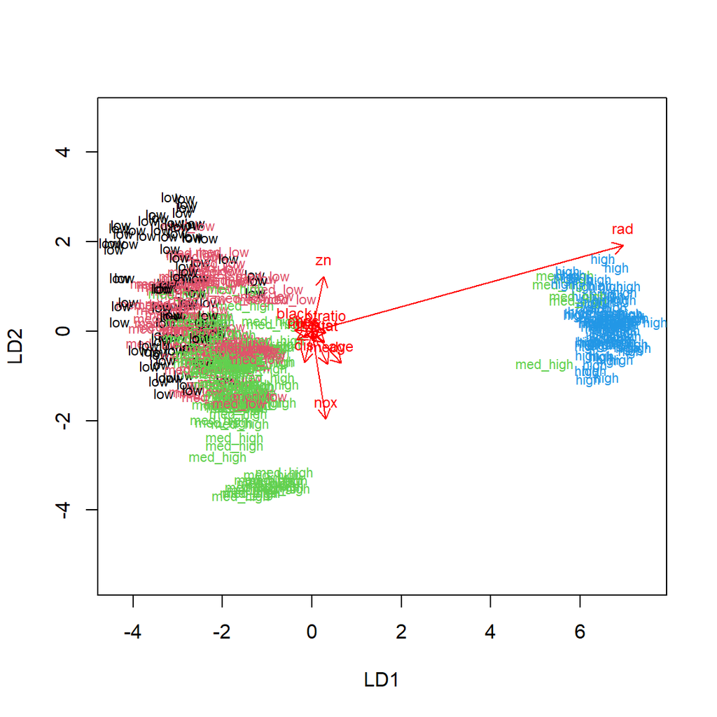

```r
# The function for LDA biplot arrows
lda.arrows <- function(x, myscale = 1, arrow_heads = 0.1, color = "red", tex = 0.75, choices = c(1,2)){
  heads <- coef(x)
  arrows(x0 = 0, y0 = 0,
         x1 = myscale * heads[,choices[1]],
         y1 = myscale * heads[,choices[2]], col=color, length = arrow_heads)
  text(myscale * heads[,choices], labels = row.names(heads),
       cex = tex, col=color, pos=3)
}

# Target classes as numeric
classes <- as.numeric(train$crime)

# Plot the LDA results
plot(lda.fit, dimen = 2, col = classes, pch = classes)
lda.arrows(lda.fit, myscale = 2)
```

The biplot picture above illustrates well that LD1 classifies very well the group having high crime rate, as the variable ‘rad’ (index of accessibility to radial highways) is extremely important predictor there. LD2 seems to differ clearly between average points of low, med-low and med-high crime rate, but according to this figure they can’t be perfectly clustered from each other. That’s still a bit mystical picture for me, but let’s go further to the prediction part…

### Predicting the crime categories on the test data

```r
# Save the correct classes from test data:
correct_classes <- test$crime

# Remove the crime variable from test data:
test <- dplyr::select(test, -crime)

# Predict classes with test data:
lda.pred <- predict(lda.fit, newdata = test)

# Cross-tabulate the results:
table(correct = correct_classes, predicted = lda.pred$class)
```

```
##           predicted
## correct    low med_low med_high high
##   low       17       9        0    0
##   med_low    4      15        7    0
##   med_high   0       4       16    1
##   high       0       0        1   28
```

### K-means clustering

```r
# Reload data 'Boston':
data('Boston')

# Center and standardize variables, see the summaries, and change the object to data frame, and remove the dummy variable:
boston_scaled <- scale(Boston)
boston_scaled <- as.data.frame(boston_scaled)

# Calculate Euclidean distance matrix between observations:
dist_eu <- dist(boston_scaled)
summary(dist_eu)
```

```
##    Min. 1st Qu.  Median    Mean 3rd Qu.    Max.
##  0.1343  3.4625  4.8241  4.9111  6.1863 14.3970
```

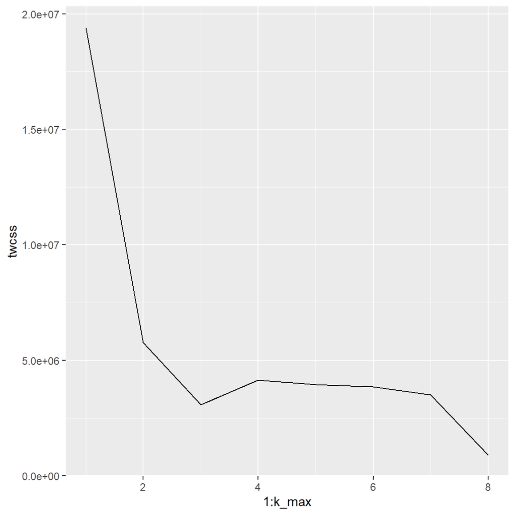

```r
# Set seed to remove randomness between different runs:
set.seed(123)

# Determine the maximum number of clusters:
k_max <- 8

# Calculate the total within sum of squares:
twcss <- sapply(1:k_max, function(k){kmeans(Boston, k)$tot.withinss})

# Visualize the results
qplot(x = 1:k_max, y = twcss, geom = 'line')
```

The optimal amount of clusters is when the value of total WCSS changes radically. The figure above shows out that in this case good number of clusters is **2**.

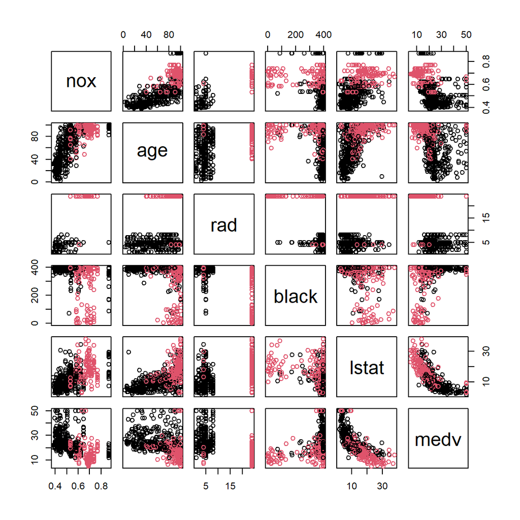

```r
# K-means clustering:
km <-kmeans(Boston, centers = 2)

# Plot the Boston data with clusters (I reduced the number of variables to make the figure readable):
pairs(Boston[c(5,7,9,12:14)], col = km$cluster)
```

Well, here it is, the end of this exercise! For the last figure I tried to find a few most interesting variables. Clearly variable ‘rad’ is the most significant variable here, and it clusters the data well to two clusters. But also we can see that especially variables ‘age’, ‘lstat’ and ‘medv’ can give extra information for clustering process, as the cluster centers are significantly different.

See you next week again! :-)

# WEEK 5: Dimensionality reduction techniques

In this exercise I was using data sets of human development and gender inequality. See the details from [this link](http://hdr.undp.org/en/content/human-development-index-hdi).

```r
# Set working directory:
setwd("C:/Users/mikniemi/OneDrive - University of Helsinki/OpenDataScience/IODS/IODS-project")

# Access the necessary tool packages:
library(dplyr)
library(corrplot)
library(GGally)
library(FactoMineR)
library(ggplot2)
library(tidyr)

# Load and explore the exercise data:
human <- read.table("Data/human.txt")
summary(human)
```

```
##   Edu2.Female     Labour.Female   Expected.Education Expected.Life
##  Min.   :  0.90   Min.   :13.50   Min.   : 5.40      Min.   :49.00
##  1st Qu.: 27.15   1st Qu.:44.45   1st Qu.:11.25      1st Qu.:66.30
##  Median : 56.60   Median :53.50   Median :13.50      Median :74.20
##  Mean   : 55.37   Mean   :52.52   Mean   :13.18      Mean   :71.65
##  3rd Qu.: 85.15   3rd Qu.:61.90   3rd Qu.:15.20      3rd Qu.:77.25
##  Max.   :100.00   Max.   :88.10   Max.   :20.20      Max.   :83.50
##       GNI         Maternal_mortality Adolescent_birth Woman_rep.Parliament
##  Min.   :   581   Min.   :   1.0     Min.   :  0.60   Min.   : 0.00
##  1st Qu.:  4198   1st Qu.:  11.5     1st Qu.: 12.65   1st Qu.:12.40
##  Median : 12040   Median :  49.0     Median : 33.60   Median :19.30
##  Mean   : 17628   Mean   : 149.1     Mean   : 47.16   Mean   :20.91
##  3rd Qu.: 24512   3rd Qu.: 190.0     3rd Qu.: 71.95   3rd Qu.:27.95
##  Max.   :123124   Max.   :1100.0     Max.   :204.80   Max.   :57.50
```

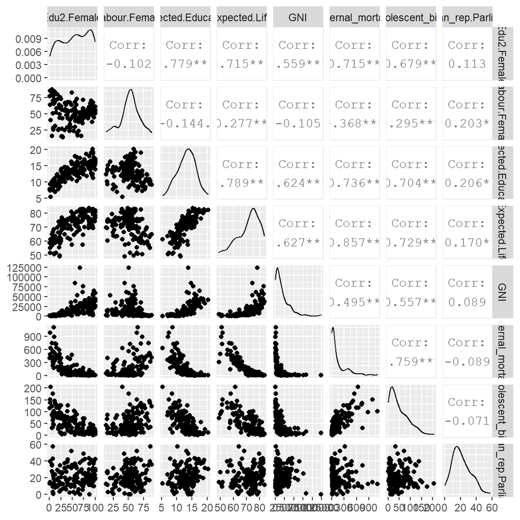

```r
ggpairs(human)
```

There are in total 8 variables explaining human development: 1) **Percentage of females having secondary education**, 2) **Percentage of females being employed**, 3) **Expected years of schooling**, 4) **Expected life**, 5) **The gross national income (GNI) Index**, 6) **Maternal mortality**, 7) **Adolescent birth**, and 8) **Female representation in parliament**. The figure above illustrates correlations between each pair of variables.

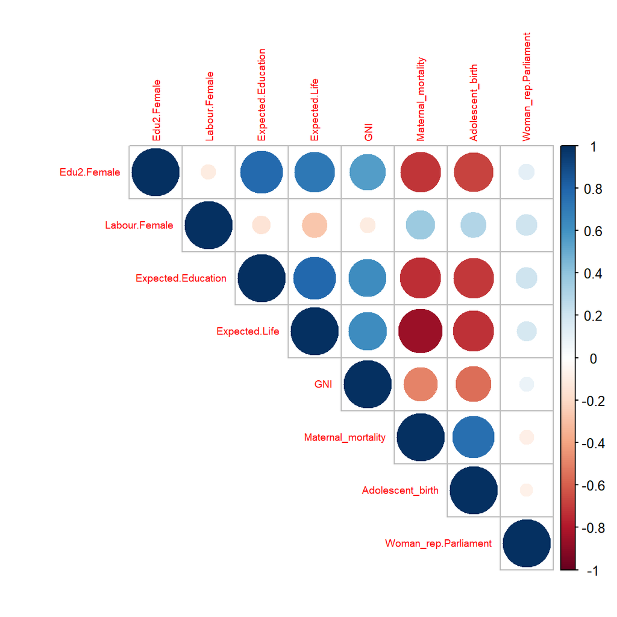

```r
# Compute the correlation matrix and visualize it with corrplot:
cor(human) %>% corrplot(type = "upper", tl.cex=0.6)
```

This figure presents well, that variables ‘Labour.Female’ and ‘Woman_rep.Parliament’ have low correlations with all other variables, but otherwise the variables are correlating with each other quite much.

### Principal Component Analysis (PCA) on the human data

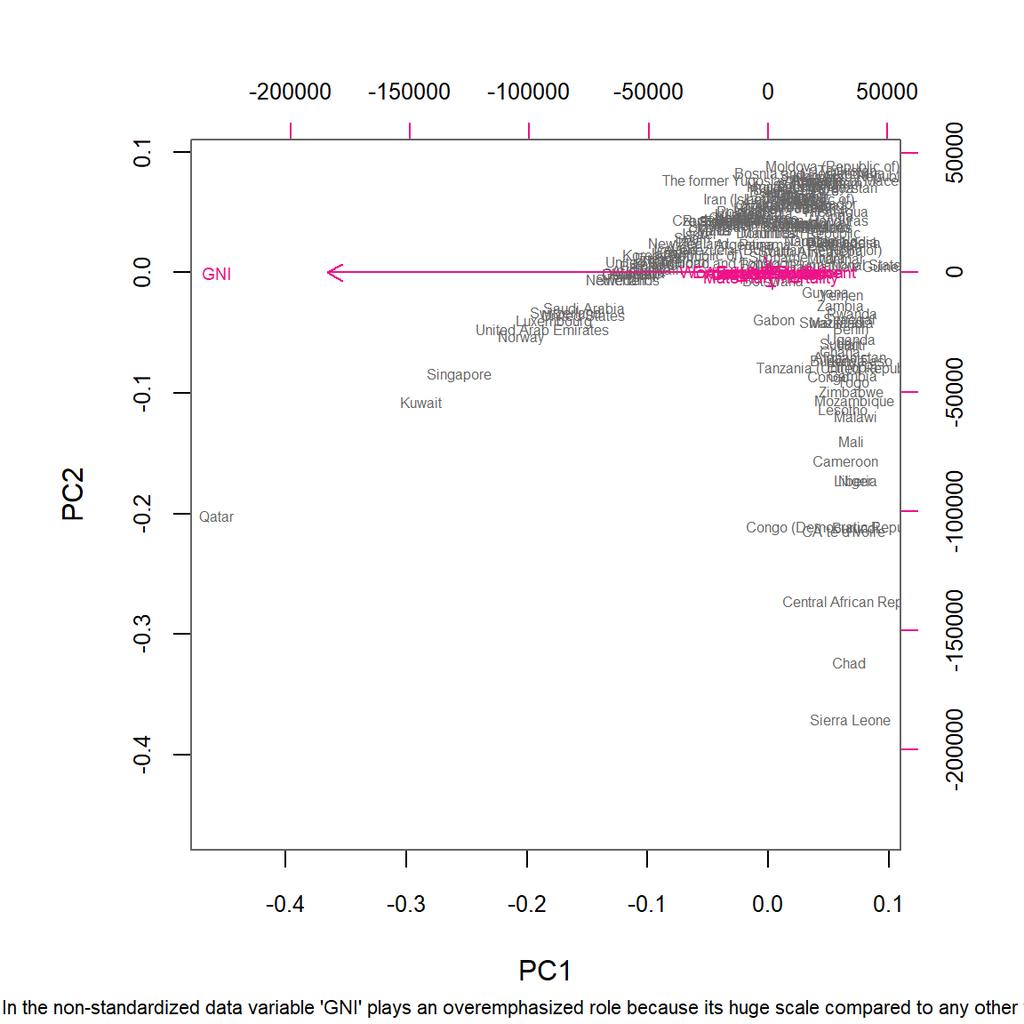

```r
# Perform principal component analysis on the not standardized data (SVD method):
pca_human <- prcomp(human)

# Draw a biplot of the principal component representation and the original variables
biplot(pca_human, choices = 1:2, cex = c(0.5, 0.6), col = c("grey40", "deeppink2"), sub = "In the non-standardized data variable 'GNI' plays an overemphasized role because its huge scale compared to any other variable", cex.sub = 0.7, cex.axis = 0.8)
```

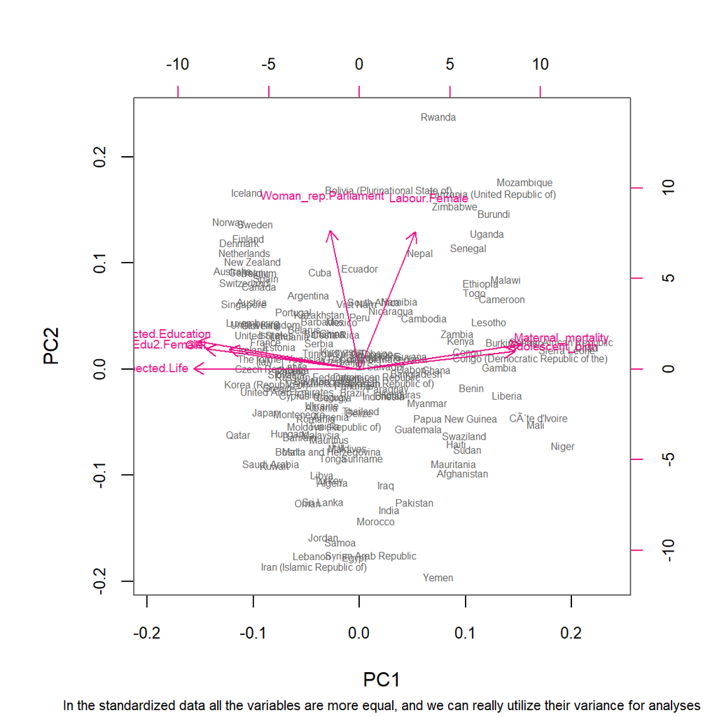

```r
# Standardize the variables:
human_std <- scale(human)

# Perform principal component analysis on the standardized data (SVD method):
pca_human_std <- prcomp(human_std)

# Draw a biplot of the principal component representation and the original variables:
biplot(pca_human_std, choices = 1:2, cex = c(0.5, 0.6), col = c("grey40", "deeppink2"), sub = "In the standardized data all the variables are more equal, and we can really utilize their variance for analyses", cex.sub = 0.7, cex.axis = 0.8)
```

Two figures above shows out how important it is to scale variables before principal component analysis. The latter figure illustrates also well the mutual correlations between some variables, as **in total six original features are contributing on the same dimension**, and therefore we could just pick up one of them to explain most variation of principal component PC1. Just two original features: *female labour and woman reps in parliament*, contribute on the vertical dimension and can explain variation of PC2.

```r
# Calculate summary of principal component analysis:
s <- summary(pca_human_std)

# Calculate and print out rounded percentages of variance captured by each PC:
pca_pr <- round(1*s$importance[2, ]*100, digits = 1)
pca_pr
```

```
##  PC1  PC2  PC3  PC4  PC5  PC6  PC7  PC8
## 57.0 15.6  9.6  6.5  3.8  3.5  2.5  1.4
```

Wow!! **57.0 % of the variation in the data could be explained by just one principal component**. By two components we could explain 72.6 % of the variation.

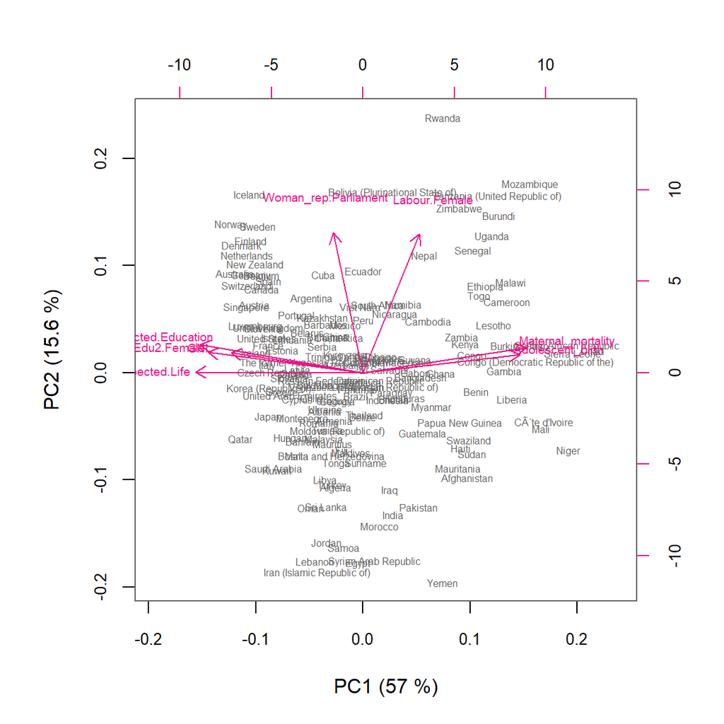

```r
# Let's adjust biplot by creating object 'pc_lab' to be used as axis labels:
pc_lab <- paste0(names(pca_pr), " (", pca_pr, " %)")

# draw a biplot
biplot(pca_human_std, cex = c(0.5, 0.6), col = c("grey40", "deeppink2"), cex.axis = 0.8, xlab = pc_lab[1], ylab = pc_lab[2])
```

### Multiple Correspondence Analysis (MCA) on the tea data

In contrast to PCA, in MCA we can use also **discrete variables**, even at *nominal scale*. For this exercise I load data ‘tea’ from the R package of ‘FactoMineR’.

```r
# Load the tea data:
data("tea")

# Look at the summary and structure of the data:
summary(tea)
```

```
##          breakfast           tea.time          evening          lunch
##  breakfast    :144   Not.tea time:131   evening    :103   lunch    : 44
##  Not.breakfast:156   tea time    :169   Not.evening:197   Not.lunch:256
##
##
##
##
##
##         dinner           always          home           work
##  dinner    : 21   always    :103   home    :291   Not.work:213
##  Not.dinner:279   Not.always:197   Not.home:  9   work    : 87
##
##
##
##
##
##         tearoom           friends          resto          pub
##  Not.tearoom:242   friends    :196   Not.resto:221   Not.pub:237
##  tearoom    : 58   Not.friends:104   resto    : 79   pub    : 63
##
##
##
##
##
##         Tea         How           sugar                     how
##  black    : 74   alone:195   No.sugar:155   tea bag           :170
##  Earl Grey:193   lemon: 33   sugar   :145   tea bag+unpackaged: 94
##  green    : 33   milk : 63                  unpackaged        : 36
##                  other:  9
##
##
##
##                   where                 price          age        sex
##  chain store         :192   p_branded      : 95   Min.   :15.00   F:178
##  chain store+tea shop: 78   p_cheap        :  7   1st Qu.:23.00   M:122
##  tea shop            : 30   p_private label: 21   Median :32.00
##                             p_unknown      : 12   Mean   :37.05
##                             p_upscale      : 53   3rd Qu.:48.00
##                             p_variable     :112   Max.   :90.00
##
```

[output cut: 25 more lines]

```
##  feminine    :129   Not.sophisticated: 85   No.slimming:255   exciting   :116
##  Not.feminine:171   sophisticated    :215   slimming   : 45   No.exciting:184
##
##
##
##
##
##         relaxing              effect.on.health
##  No.relaxing:113   effect on health   : 66
##  relaxing   :187   No.effect on health:234
##
##
##
##
##
```

```r
str(tea)
```

```
## 'data.frame':    300 obs. of  36 variables:
##  $ breakfast       : Factor w/ 2 levels "breakfast","Not.breakfast": 1 1 2 2 1 2 1 2 1 1 ...
##  $ tea.time        : Factor w/ 2 levels "Not.tea time",..: 1 1 2 1 1 1 2 2 2 1 ...
##  $ evening         : Factor w/ 2 levels "evening","Not.evening": 2 2 1 2 1 2 2 1 2 1 ...
##  $ lunch           : Factor w/ 2 levels "lunch","Not.lunch": 2 2 2 2 2 2 2 2 2 2 ...
##  $ dinner          : Factor w/ 2 levels "dinner","Not.dinner": 2 2 1 1 2 1 2 2 2 2 ...
##  $ always          : Factor w/ 2 levels "always","Not.always": 2 2 2 2 1 2 2 2 2 2 ...
##  $ home            : Factor w/ 2 levels "home","Not.home": 1 1 1 1 1 1 1 1 1 1 ...
##  $ work            : Factor w/ 2 levels "Not.work","work": 1 1 2 1 1 1 1 1 1 1 ...
##  $ tearoom         : Factor w/ 2 levels "Not.tearoom",..: 1 1 1 1 1 1 1 1 1 2 ...
##  $ friends         : Factor w/ 2 levels "friends","Not.friends": 2 2 1 2 2 2 1 2 2 2 ...
##  $ resto           : Factor w/ 2 levels "Not.resto","resto": 1 1 2 1 1 1 1 1 1 1 ...
##  $ pub             : Factor w/ 2 levels "Not.pub","pub": 1 1 1 1 1 1 1 1 1 1 ...
##  $ Tea             : Factor w/ 3 levels "black","Earl Grey",..: 1 1 2 2 2 2 2 1 2 1 ...
##  $ How             : Factor w/ 4 levels "alone","lemon",..: 1 3 1 1 1 1 1 3 3 1 ...
```

[output cut: 22 more lines]

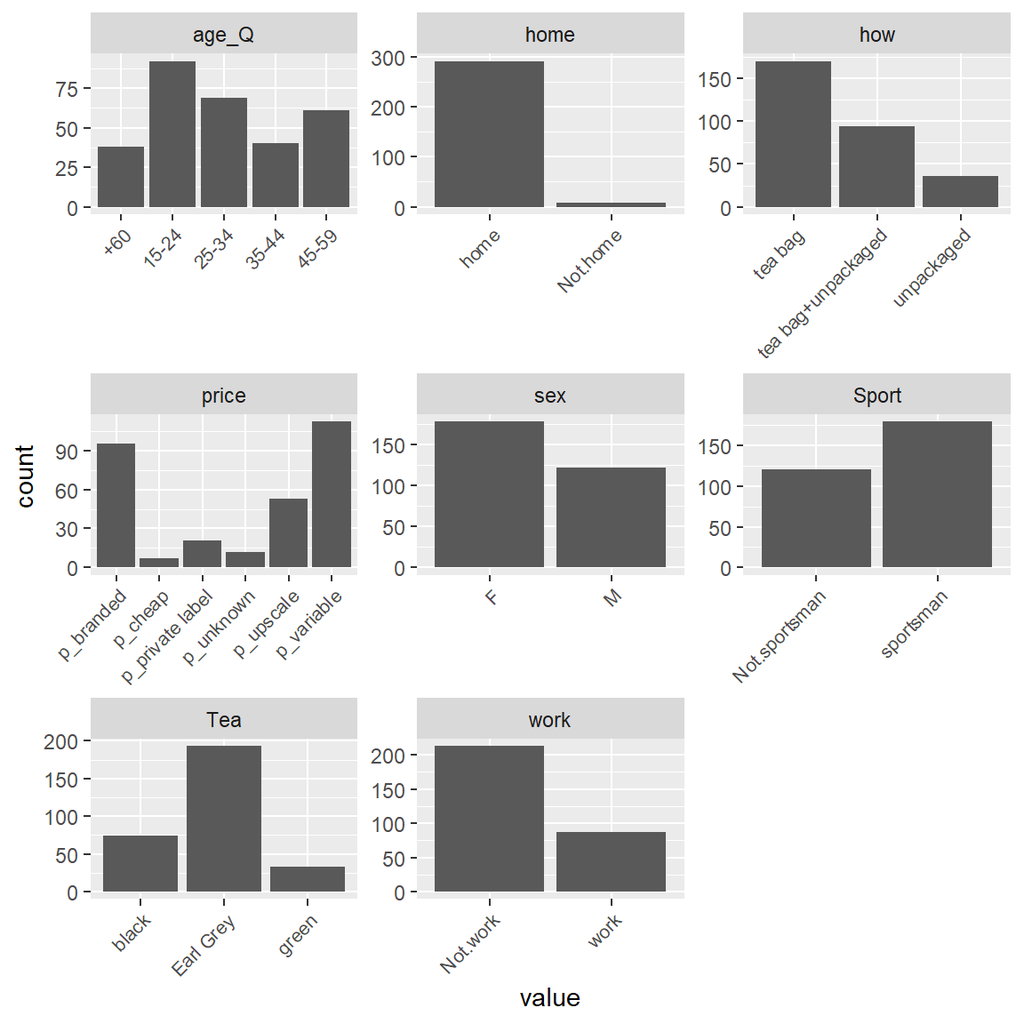

```r
# Select some variables that I'm interested in:
keep_columns <- c("Tea", "how", "home", "work", "price", "sex", "Sport", "age_Q")
tea_selection <- dplyr::select(tea, one_of(keep_columns))

# Visualize the data of the selected columns
gather(tea_selection) %>% ggplot(aes(value)) + facet_wrap("key", scales = "free") + geom_bar() + theme(axis.text.x = element_text(angle = 45, hjust = 1, size = 8))
```

```r
# Perform Multiple Correspondence Analysis and look at the summary of the model
mca <- MCA(tea_selection, graph = FALSE)
summary(mca)
```

```
##
## Call:
## MCA(X = tea_selection, graph = FALSE)
##
##
## Eigenvalues
##                        Dim.1   Dim.2   Dim.3   Dim.4   Dim.5   Dim.6   Dim.7
## Variance               0.228   0.199   0.165   0.158   0.148   0.143   0.132
## % of var.             10.732   9.360   7.755   7.454   6.971   6.740   6.203
## Cumulative % of var.  10.732  20.092  27.847  35.302  42.272  49.013  55.216
##                        Dim.8   Dim.9  Dim.10  Dim.11  Dim.12  Dim.13  Dim.14
## Variance               0.125   0.119   0.112   0.104   0.100   0.098   0.090
## % of var.              5.900   5.604   5.266   4.905   4.687   4.630   4.231
## Cumulative % of var.  61.116  66.719  71.985  76.891  81.577  86.207  90.438
##                       Dim.15  Dim.16  Dim.17
## Variance               0.080   0.065   0.058
## % of var.              3.780   3.074   2.708
## Cumulative % of var.  94.218  97.292 100.000
##
## Individuals (the 10 first)
##                       Dim.1    ctr   cos2    Dim.2    ctr   cos2    Dim.3
## 1                  |  0.220  0.071  0.010 | -0.044  0.003  0.000 | -0.054
## 2                  |  0.136  0.027  0.013 | -0.143  0.034  0.015 | -0.073
## 3                  | -0.425  0.264  0.134 |  0.171  0.049  0.022 | -0.212
## 4                  | -0.273  0.109  0.069 | -0.212  0.075  0.041 |  0.175
## 5                  | -0.067  0.007  0.004 |  0.146  0.036  0.018 |  0.334
## 6                  | -0.384  0.216  0.061 | -0.046  0.004  0.001 |  0.672
## 7                  | -0.071  0.007  0.003 |  0.132  0.029  0.012 | -0.197
## 8                  |  0.132  0.026  0.010 | -0.157  0.041  0.014 | -0.604
## 9                  |  0.379  0.209  0.070 |  0.464  0.360  0.104 | -0.367
## 10                 |  0.817  0.975  0.270 |  0.089  0.013  0.003 | -0.742
##                       ctr   cos2
## 1                   0.006  0.001 |
## 2                   0.011  0.004 |
## 3                   0.091  0.033 |
## 4                   0.062  0.028 |
## 5                   0.225  0.094 |
## 6                   0.913  0.186 |
## 7                   0.079  0.026 |
## 8                   0.738  0.212 |
```

[output cut: 22 more lines]

```
## home                -5.273 |  -0.048   0.169   0.074  -4.716 |
## Not.home             5.273 |   1.551   5.472   0.074   4.716 |
## Not.work            -6.447 |   0.272   3.995   0.182   7.369 |
## work                 6.447 |  -0.667   9.782   0.182  -7.369 |
##
## Categorical variables (eta2)
##                      Dim.1 Dim.2 Dim.3
## Tea                | 0.420 0.023 0.107 |
## how                | 0.351 0.253 0.122 |
## home               | 0.002 0.093 0.074 |
## work               | 0.116 0.139 0.182 |
## price              | 0.417 0.264 0.121 |
## sex                | 0.092 0.129 0.167 |
## Sport              | 0.019 0.258 0.128 |
## age_Q              | 0.408 0.432 0.416 |
```

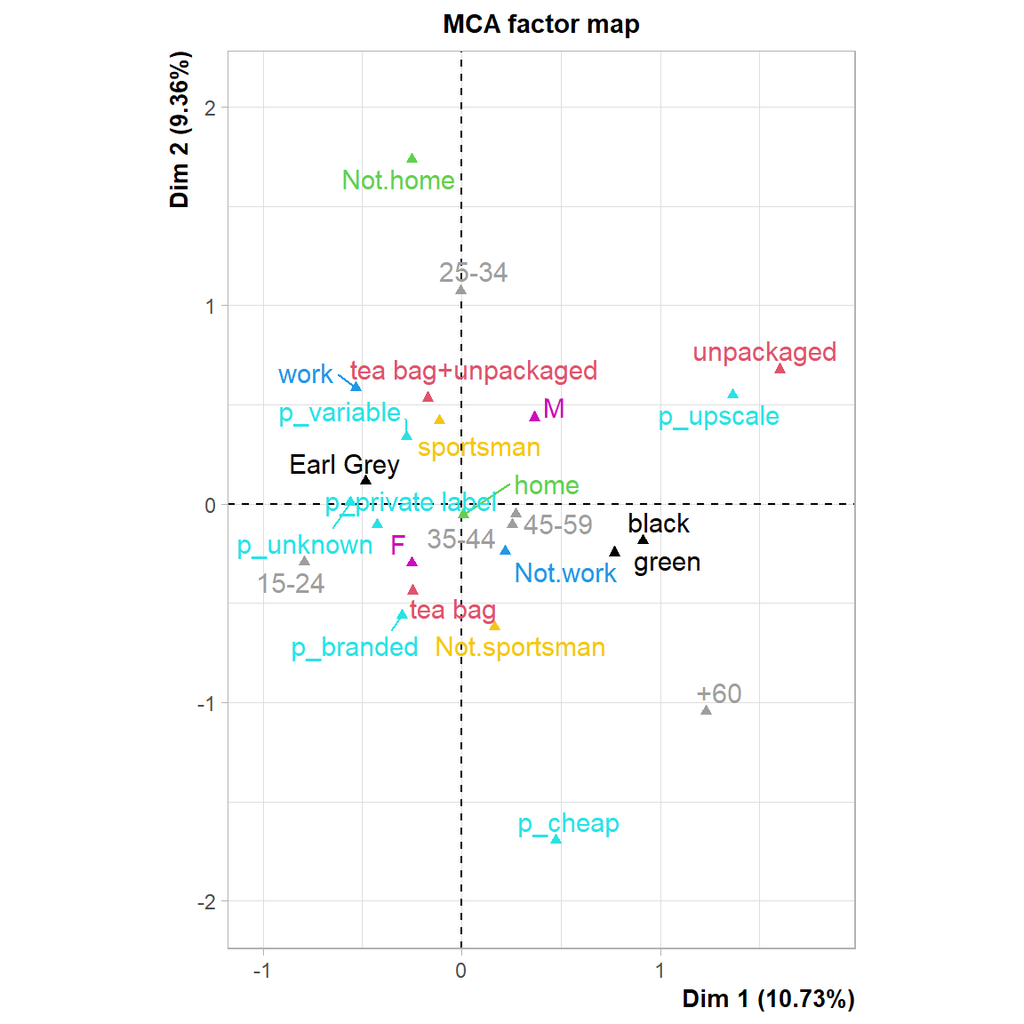

```r
# Visualize MCA
plot(mca, invisible=c("ind"), habillage = "quali")
```

The MCA summary tells that 10.7 % of the data variation could be explained by one dimension, 20.1 % by two dimensions, e.g… In total 17 dimensions are needed to cover all the data variation. The MCA biplot shows the distances between different properties, and we can see that e.g. features ‘p_cheap’, ‘+60’ and ‘Not.home’ are far from any other feature. Otherwise we can also see that e.g. people who use unpacked tea, are also ready to buy tea at upscale price. Also we can see how well different dimensions can classify different features: e.g. Earl Grey drinkers can be separated from black and green tea drinkers by using dimension 1, but green and black tea drinkers are more difficult to recognize from each other using these two first dimensions.

# WEEK 6: Analysis of longitudinal data

Last but not least week! First I read in two data sets that I just wrangled to longitudinal form.

```r
# Set working directory:
setwd("C:/Users/mikniemi/OneDrive - University of Helsinki/OpenDataScience/IODS/IODS-project")

# Access the necessary tool packages:
library(dplyr)
library(tidyr)
library(ggplot2)
library(lme4)

# Load, factor and look at the data sets:
BPRS <- read.table("Data/BPRS.txt")
BPRSL <- read.table("Data/BPRSL.txt")
BPRSL$treatment <- factor(BPRSL$treatment)
# Fix the data set such as every individual has its own subject number:
for(i in 1:nrow(BPRSL)){
  if(BPRSL[i,"treatment"] == 2){
    BPRSL[i,"subject"] <- BPRSL[i,"subject"] + 20
  }
}
BPRSL$subject <- factor(BPRSL$subject)
glimpse(BPRSL)
```

```
## Rows: 360
## Columns: 5
## $ treatment <fct> 1, 1, 1, 1, 1, 1, 1, 1, 1, 1, 1, 1, 1, 1, 1, 1, 1, 1, 1, ...
## $ subject   <fct> 1, 2, 3, 4, 5, 6, 7, 8, 9, 10, 11, 12, 13, 14, 15, 16, 17...
## $ weeks     <chr> "week0", "week0", "week0", "week0", "week0", "week0", "we...
## $ bprs      <int> 42, 58, 54, 55, 72, 48, 71, 30, 41, 57, 30, 55, 36, 38, 6...
## $ week      <int> 0, 0, 0, 0, 0, 0, 0, 0, 0, 0, 0, 0, 0, 0, 0, 0, 0, 0, 0, ...
```

```r
RATS <- read.table("Data/RATS.txt")
RATSL <- read.table("Data/RATSL.txt")
RATSL$ID <- factor(RATSL$ID)
RATSL$Group <- factor(RATSL$Group)
glimpse(RATSL)
```

```
## Rows: 176
## Columns: 5
## $ ID     <fct> 1, 2, 3, 4, 5, 6, 7, 8, 9, 10, 11, 12, 13, 14, 15, 16, 1, 2,...
## $ Group  <fct> 1, 1, 1, 1, 1, 1, 1, 1, 2, 2, 2, 2, 3, 3, 3, 3, 1, 1, 1, 1, ...
## $ WD     <chr> "WD1", "WD1", "WD1", "WD1", "WD1", "WD1", "WD1", "WD1", "WD1...
## $ Weight <int> 240, 225, 245, 260, 255, 260, 275, 245, 410, 405, 445, 555, ...
## $ Time   <int> 1, 1, 1, 1, 1, 1, 1, 1, 1, 1, 1, 1, 1, 1, 1, 1, 8, 8, 8, 8, ...
```

There are glimpses of these two data sets above. The first data set **BPRSL** contains weekly measures of 40 males assigned to two treatment groups (1 or 2). The data is used to evaluate patients suspected having schizophrenia. The lower value of BPRS (minimum 18) means the less symptoms of schizophrenia present. The latter data set **RATSL** contains weekly weight measurements (in grams) of rats divided into three groups having different diets. In here we are interested if different diets effects to rats’ growth.

### Summary Measure Approach using the RATSL data

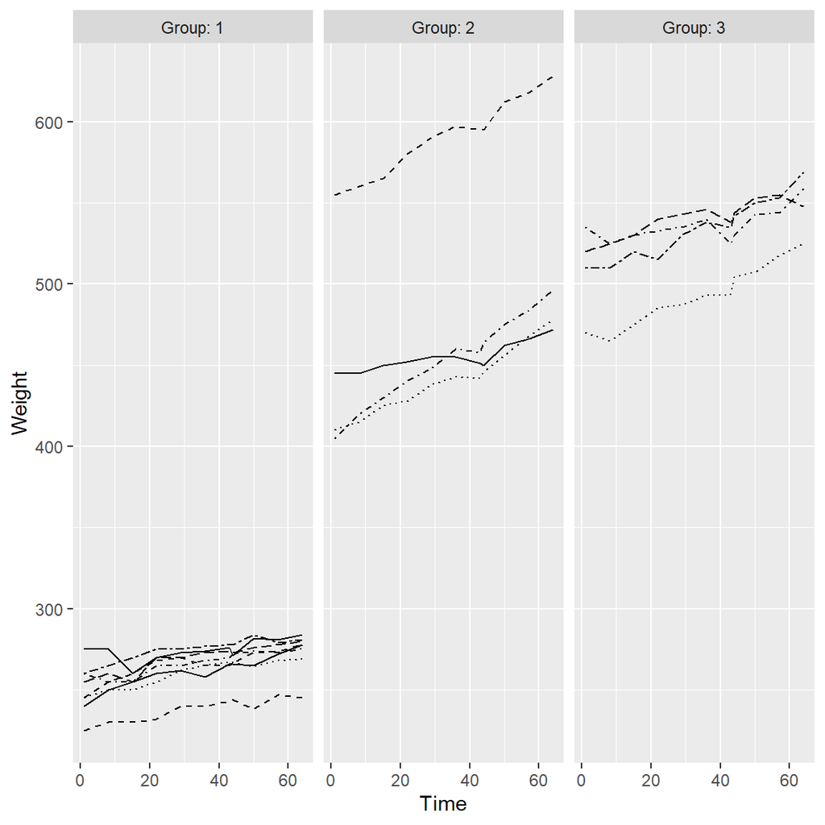

```r
# Draw the plot:
ggplot(RATSL, aes(x = Time, y = Weight, linetype = ID)) +
  geom_line() +
  scale_linetype_manual(values = rep(1:10, times=4)) +
  facet_grid(. ~ Group, labeller = label_both) +
  theme(legend.position = "none") +
  scale_y_continuous(limits = c(min(RATSL$Weight), max(RATSL$Weight)))
```

**Figure 1.** Individual response profiles by diet group for the RATS data.

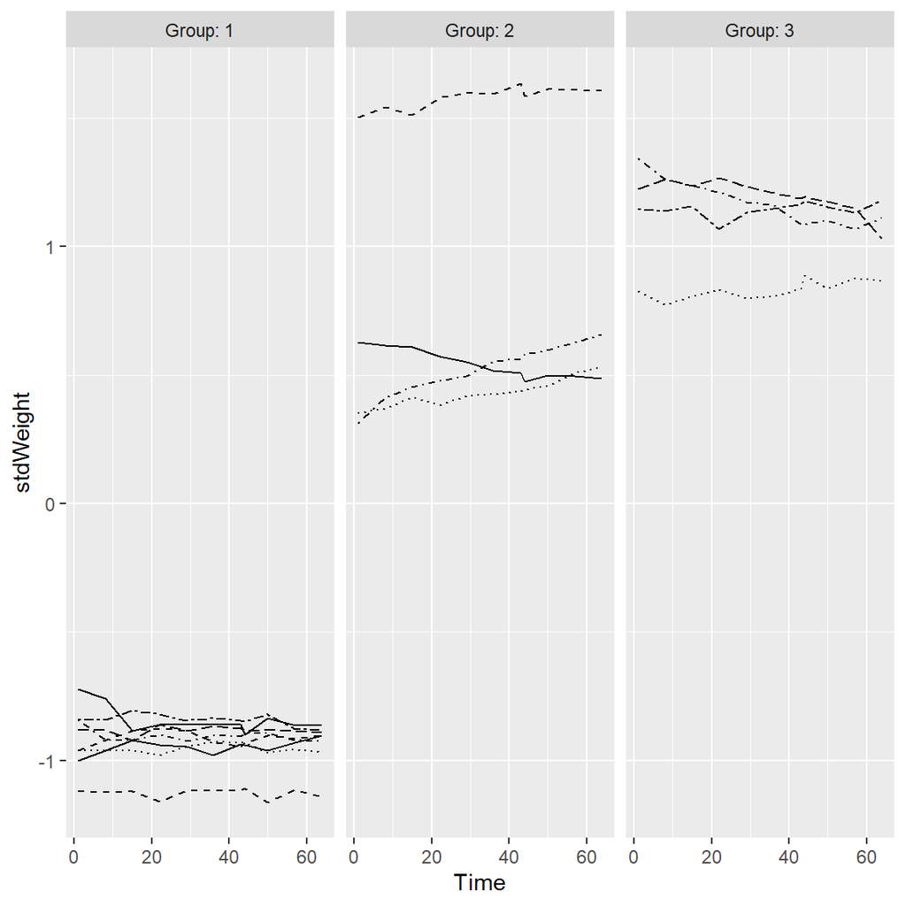

```r
# Standardise the variable Weight:
RATSL <- RATSL %>%
  group_by(Time) %>%
  mutate(stdWeight = (Weight - mean(Weight))/sd(Weight) ) %>%
  ungroup()

# Plot again with the standardized weights:
ggplot(RATSL, aes(x = Time, y = stdWeight, linetype = ID)) +
  geom_line() +
  scale_linetype_manual(values = rep(1:10, times=4)) +
  facet_grid(. ~ Group, labeller = label_both) +
  theme(legend.position = "none") +
  scale_y_continuous(limits = c(min(RATSL$stdWeight), max(RATSL$stdWeight)))
```

**Figure 2.** The corresponding individual response profiles after standardization.

```r
# Number of measurement times:
n <- RATSL$Time %>% unique() %>% length()

# Summary data with mean and standard error of Weight by Group and Time:
RATSS <- RATSL %>%
  group_by(Group, Time) %>%
  summarise( mean = mean(Weight), se = sd(Weight)/sqrt(n) ) %>%
  ungroup()

# Glimpse the data:
glimpse(RATSS)
```

```
## Rows: 33
## Columns: 4
## $ Group <fct> 1, 1, 1, 1, 1, 1, 1, 1, 1, 1, 1, 2, 2, 2, 2, 2, 2, 2, 2, 2, 2...
## $ Time  <int> 1, 8, 15, 22, 29, 36, 43, 44, 50, 57, 64, 1, 8, 15, 22, 29, 3...
## $ mean  <dbl> 250.625, 255.000, 254.375, 261.875, 264.625, 265.000, 267.375...
## $ se    <dbl> 4.589478, 3.947710, 3.460116, 4.100800, 3.333956, 3.552939, 3...
```

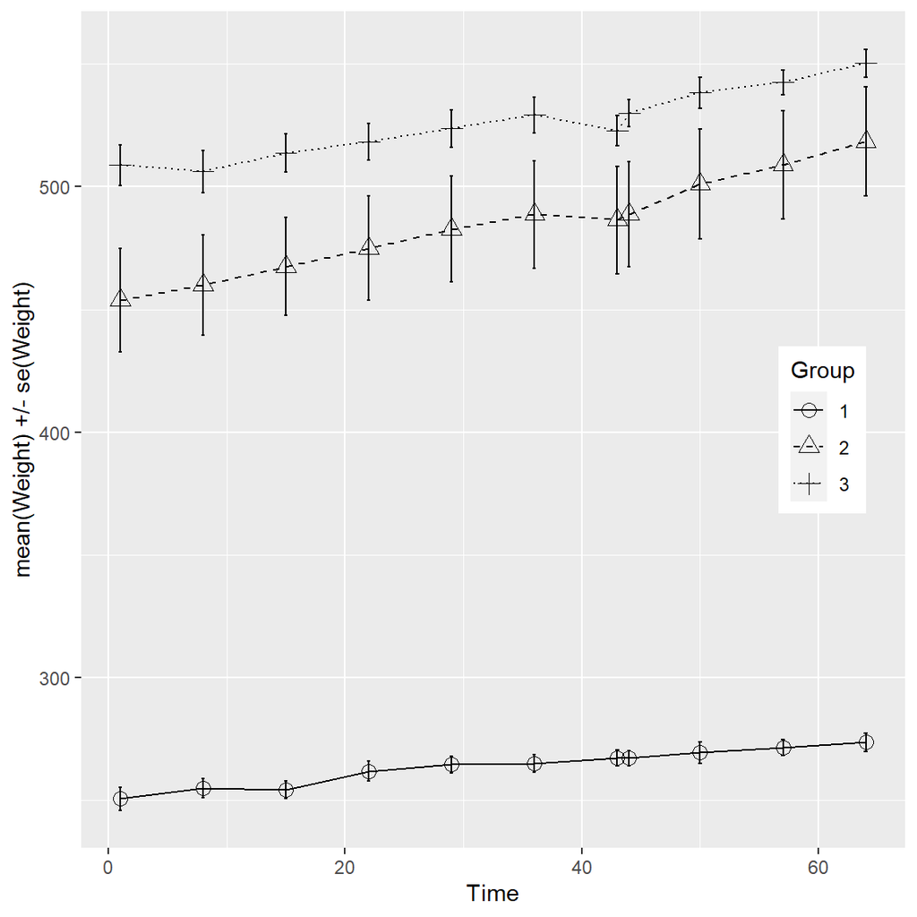

```r
# Plot the mean profiles:
ggplot(RATSS, aes(x = Time, y = mean, linetype = Group, shape = Group)) +
  geom_line() +
  scale_linetype_manual(values = c(1,2,3)) +
  geom_point(size=3) +
  scale_shape_manual(values = c(1,2,3)) +
  geom_errorbar(aes(ymin=mean-se, ymax=mean+se, linetype="1"), width=0.3) +
  theme(legend.position = c(0.9,0.5)) +
  scale_y_continuous(name = "mean(Weight) +/- se(Weight)")
```

**Figure 3.** Summarized mean response profiles of the three diet groups. Error bars illustrates the standard errors of mean.

```r
# Create a summary data by Group and ID with mean as the summary variable (ignoring baseline WD1):
RATSLWDS <- RATSL %>%
  filter(Time > 1) %>%
  group_by(Group, ID) %>%
  summarise( mean=mean(Weight) ) %>%
  ungroup()

# Glimpse the data:
glimpse(RATSLWDS)
```

```
## Rows: 16
## Columns: 3
## $ Group <fct> 1, 1, 1, 1, 1, 1, 1, 1, 2, 2, 2, 2, 3, 3, 3, 3
## $ ID    <fct> 1, 2, 3, 4, 5, 6, 7, 8, 9, 10, 11, 12, 13, 14, 15, 16
## $ mean  <dbl> 263.2, 238.9, 261.7, 267.2, 270.9, 276.2, 274.6, 267.5, 443.9...
```

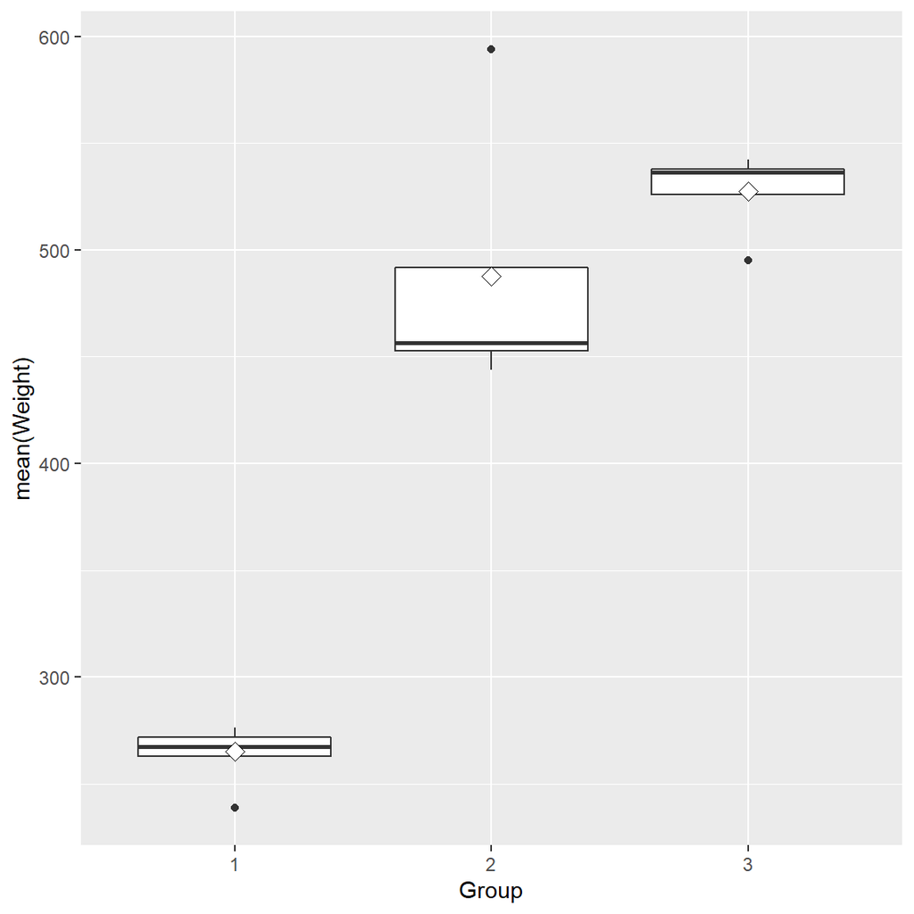

```r
# Draw a boxplot of the mean versus treatment:
ggplot(RATSLWDS, aes(x = Group, y = mean)) +
  geom_boxplot() +
  stat_summary(fun.y = "mean", geom = "point", shape=23, size=3, fill = "white") +
  scale_y_continuous(name = "mean(Weight)")
```

**Figure 4.** Possible outliers of the three groups can be detected from the boxplots above.

```r
# Add the baseline (WD1) from the original data as a new variable to the summary data:
RATSLWDS1 <- RATSLWDS %>%
  mutate(baseline = RATS$WD1)

# Fit the linear model with the mean as the response variable:
fit <- lm(mean ~ baseline + Group, data = RATSLWDS1)

# Compute the analysis of variance table for the fitted model with anova():
anova(fit)
```

```
## Analysis of Variance Table
##
## Response: mean
##           Df Sum Sq Mean Sq   F value   Pr(>F)
## baseline   1 253625  253625 1859.8201 1.57e-14 ***
## Group      2    879     439    3.2219  0.07586 .
## Residuals 12   1636     136
## ---
## Signif. codes:  0 '***' 0.001 '**' 0.01 '*' 0.05 '.' 0.1 ' ' 1
```

### Linear Mixed Effects Models using using the BPRSL data

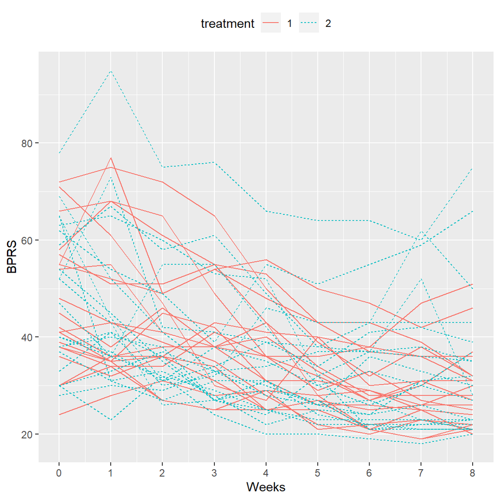

```r
# Plot the BPRSL data:
ggplot(BPRSL, aes(x = week, y = bprs, group = subject)) +
  geom_line(aes(linetype = treatment, color = treatment)) +
  scale_x_continuous(name = "Weeks", breaks = seq(0, 8, 1)) +
  scale_y_continuous(name = "BPRS", breaks = seq(0, 100, 20)) +
  theme(legend.position = "top")
```

**Figure 5.** Plot of BPRS indexes against time. Individuals having different treatments are illustrated by different line types and colors.

```r
# Create a regression model BPRS_reg and print out the model summary:
BPRS_reg <- lm(bprs ~ week + treatment, data = BPRSL)
summary(BPRS_reg)
```

```
##
## Call:
## lm(formula = bprs ~ week + treatment, data = BPRSL)
##
## Residuals:
##     Min      1Q  Median      3Q     Max
## -22.454  -8.965  -3.196   7.002  50.244
##
## Coefficients:
##             Estimate Std. Error t value Pr(>|t|)
## (Intercept)  46.4539     1.3670  33.982   <2e-16 ***
## week         -2.2704     0.2524  -8.995   <2e-16 ***
## treatment2    0.5722     1.3034   0.439    0.661
## ---
## Signif. codes:  0 '***' 0.001 '**' 0.01 '*' 0.05 '.' 0.1 ' ' 1
##
## Residual standard error: 12.37 on 357 degrees of freedom
## Multiple R-squared:  0.1851, Adjusted R-squared:  0.1806
## F-statistic: 40.55 on 2 and 357 DF,  p-value: < 2.2e-16
```

**Table 2.** The summary of simple linear regression model, where BPRS is modeled using time (week) and dummy variable of treatment. According to this print, treatment would not be significantly affecting to BPRS index value. **But remember that the use of linear regression assumes that all the measurements were independent, which is not true here due to the longitudinal character of the data.**

```r
# Create a random intercept model and print out the model summary:
BPRS_ref <- lmer(bprs ~ week + treatment + (1 | subject), data = BPRSL, REML = FALSE)
summary(BPRS_ref)
```

```
## Linear mixed model fit by maximum likelihood  ['lmerMod']
## Formula: bprs ~ week + treatment + (1 | subject)
##    Data: BPRSL
##
##      AIC      BIC   logLik deviance df.resid
##   2582.9   2602.3  -1286.5   2572.9      355
##
## Scaled residuals:
##      Min       1Q   Median       3Q      Max
## -2.27506 -0.59909 -0.06104  0.44226  3.15835
##
## Random effects:
##  Groups   Name        Variance Std.Dev.
##  subject  (Intercept) 97.39    9.869
##  Residual             54.23    7.364
## Number of obs: 360, groups:  subject, 40
##
## Fixed effects:
##             Estimate Std. Error t value
## (Intercept)  46.4539     2.3521  19.750
## week         -2.2704     0.1503 -15.104
## treatment2    0.5722     3.2159   0.178
##
## Correlation of Fixed Effects:
##            (Intr) week
## week       -0.256
## treatment2 -0.684  0.000
```

```r
# Create a random intercept and random slope model, and print out the summary:
BPRS_ref1 <- lmer(bprs ~ week + treatment + (week | subject), data = BPRSL, REML = FALSE)
summary(BPRS_ref1)
```

```
## Linear mixed model fit by maximum likelihood  ['lmerMod']
## Formula: bprs ~ week + treatment + (week | subject)
##    Data: BPRSL
##
##      AIC      BIC   logLik deviance df.resid
##   2523.2   2550.4  -1254.6   2509.2      353
##
## Scaled residuals:
##     Min      1Q  Median      3Q     Max
## -2.4655 -0.5150 -0.0920  0.4347  3.7353
##
## Random effects:
##  Groups   Name        Variance Std.Dev. Corr
##  subject  (Intercept) 167.827  12.955
##           week          2.331   1.527   -0.67
##  Residual              36.747   6.062
## Number of obs: 360, groups:  subject, 40
##
## Fixed effects:
##             Estimate Std. Error t value
## (Intercept)  45.9830     2.6470  17.372
## week         -2.2704     0.2713  -8.370
## treatment2    1.5139     3.1392   0.482
##
## Correlation of Fixed Effects:
##            (Intr) week
## week       -0.545
## treatment2 -0.593  0.000
```

**Table 4.** The summary of *random intercept and random slope model* to the BPRS data. The residuals are a bit lower than corresponding results in the previous table.

```r
# Perform an ANOVA test on the two models:
anova(BPRS_ref1, BPRS_ref)
```

```
## Data: BPRSL
## Models:
## BPRS_ref: bprs ~ week + treatment + (1 | subject)
## BPRS_ref1: bprs ~ week + treatment + (week | subject)
##           npar    AIC    BIC  logLik deviance  Chisq Df Pr(>Chisq)
## BPRS_ref     5 2582.9 2602.3 -1286.5   2572.9
## BPRS_ref1    7 2523.2 2550.4 -1254.6   2509.2 63.663  2  1.499e-14 ***
## ---
## Signif. codes:  0 '***' 0.001 '**' 0.01 '*' 0.05 '.' 0.1 ' ' 1
```

```r
# Create a random intercept and random slope model with the interaction:
BPRS_ref2 <- lmer(bprs ~ week + treatment + (week | subject) + (week * treatment), data = BPRSL, REML = FALSE)
summary(BPRS_ref2)
```

```
## Linear mixed model fit by maximum likelihood  ['lmerMod']
## Formula: bprs ~ week + treatment + (week | subject) + (week * treatment)
##    Data: BPRSL
##
##      AIC      BIC   logLik deviance df.resid
##   2523.5   2554.5  -1253.7   2507.5      352
##
## Scaled residuals:
##     Min      1Q  Median      3Q     Max
## -2.4747 -0.5256 -0.0866  0.4435  3.7884
##
## Random effects:
##  Groups   Name        Variance Std.Dev. Corr
##  subject  (Intercept) 164.204  12.814
##           week          2.203   1.484   -0.66
##  Residual              36.748   6.062
## Number of obs: 360, groups:  subject, 40
##
## Fixed effects:
##                 Estimate Std. Error t value
## (Intercept)      47.8856     2.9840  16.047
## week             -2.6283     0.3752  -7.006
## treatment2       -2.2911     4.2200  -0.543
## week:treatment2   0.7158     0.5306   1.349
##
## Correlation of Fixed Effects:
##             (Intr) week   trtmn2
## week        -0.668
## treatment2  -0.707  0.473
## wek:trtmnt2  0.473 -0.707 -0.668
```

**Table 6.** Summary of *a random intercept and random slope model with the interaction of week and treatment*

```r
# Perform an ANOVA test on the two models:
anova(BPRS_ref2, BPRS_ref1)
```

```
## Data: BPRSL
## Models:
## BPRS_ref1: bprs ~ week + treatment + (week | subject)
## BPRS_ref2: bprs ~ week + treatment + (week | subject) + (week * treatment)
##           npar    AIC    BIC  logLik deviance Chisq Df Pr(>Chisq)
## BPRS_ref1    7 2523.2 2550.4 -1254.6   2509.2
## BPRS_ref2    8 2523.5 2554.6 -1253.7   2507.5  1.78  1     0.1821
```

**Table 7.** ANOVA test reveals that the interaction of week and treatment does not improve model fit in this BPRS data.

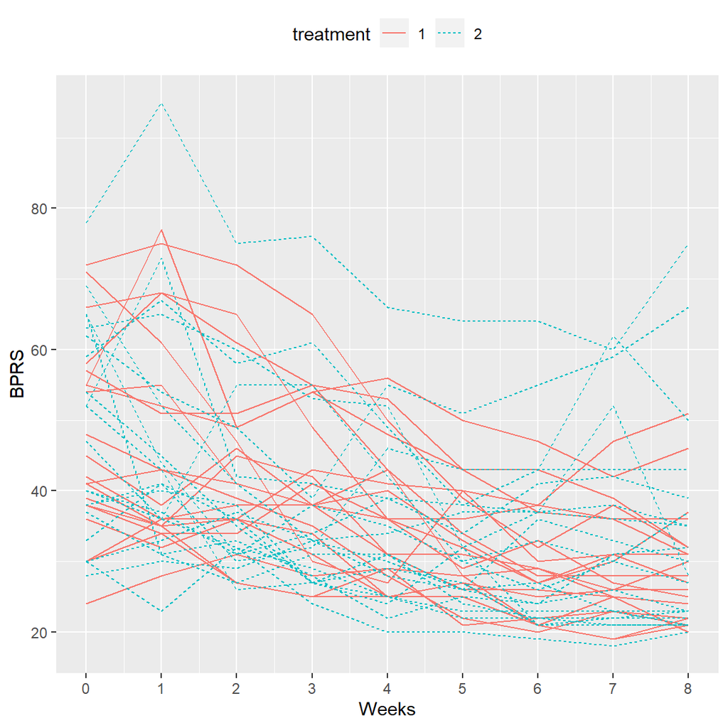

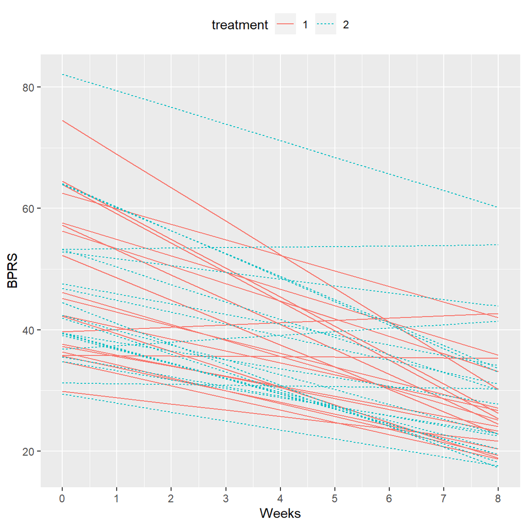

```r
par(mar = c(4, 4, .1, .1))

# Draw the plot of BPRSL with the observed Weight values:
ggplot(BPRSL, aes(x = week, y = bprs, group = subject)) +
  geom_line(aes(linetype = treatment, color = treatment)) +
  scale_x_continuous(name = "Weeks", breaks = seq(0, 8, 1)) +
  scale_y_continuous(name = "BPRS", breaks = seq(0, 100, 20)) +
  theme(legend.position = "top")

# Create a vector of the fitted values (ref1):
Fitted <- fitted(BPRS_ref1)

# Create a new column fitted to RATSL:
BPRSL <- mutate(BPRSL, fitted = Fitted)

# Draw the plot of BPRSL with the Fitted values of weight:
ggplot(BPRSL, aes(x = week, y = fitted, group = subject)) +
  geom_line(aes(linetype = treatment, color = treatment)) +
  scale_x_continuous(name = "Weeks", breaks = seq(0, 8, 1)) +
  scale_y_continuous(name = "BPRS", breaks = seq(0, 100, 20)) +
  theme(legend.position = "top")
```

**Figure 6.** The observed BPRS values on the left side, and the predicted BPRS values on the right hand side. In this figure I used *the random intercept and random slope model* for prediction since according to my previous interpretations that one works best in BPRS data.

## Greetings!

**Kimmo and the team! Thank you a lot for the useful course! :-)**